# Request by Alexander Braun from 18-Feb-2026

Interrupted Time Series - Segmented linear regression // Nonparametric regression

Author

Claus P. Nowak

Published

22 June 2026

# Preliminary/Which data do I use?

**Update 22-Jun-2026**. Based on the reviewers comments we received on 22 June 2026, i.e.,

- Day-of-week effects: Daily data over four years will exhibit strong within-week perio-dicity (weekday vs. weekend admission volumes differ substantially). This is not mod-elled. Day-of-week fixed effects should be included, or the authors must justify their omission.
- Public holidays and the Christmas/New Year period: The interruption point (January 2024) coincides with a known seasonal peak in ED presentations (cited references 29 and 30). The influenza adjustment does not capture post-holiday effects. A holiday dummy should be considered.

I have rerun the ITS regression analysis accounting for holiday and day of the week. To this end, Alexander Braun has sent me an Excel sheet `Feiertage_AT_Taggenau_2022_2025.xlsx`.

$$y_t = \beta_0 + \beta_1 t+\beta_2I_t+\beta_3(t-T)I_t + \beta_4F_t+ \beta_5H_t+\gamma_kWD_{k_t}+\varepsilon_t,$$
where

- $y_t$ is the number of hospital admissions at day $t=1,..,n$;
- $T$ is the interruption day, in our case $T=731$,
- $I_t$ is an indicator variable which takes 0 before the interruption, i.e., if $t < T$, and 1 otherwise,
- $F_{t}$ is an indicator variable (whether the day is during influenza period (1=yes, 0=no))
- $H_{t}$ is an indicator variable (whether the day is a public holiday in Austria (1=yes, 0=no))
- $WD_{k_{t}}$ are six indicator variables $k=2,...,7$ (whether the day is a particular day of the week (Tuesday,…,Sunday; yes=1, no=0).
- $\varepsilon_t$ are modelled as autocorrelated errors of order 1.

**Update 17-Jun-2026**. Based on the reviewer comments from 15 June 2026, we were asked to

- run the regression again excluding weekends as a robustness check
  - use weekend ED admission rates to check the plausibility of their estimated counterfactual trend,
- perform an additional analysis distinguishing between visits during the opening hours of the PHCC,
  - that is, when it was actually available as a substitute.

In this regard, I have performed the ITS and the nonparametric trend analysis again, treating Saturdays and Sundays as missing values, i.e., I have deleted the corresponding rows from the data set. Conversely, I have also deleted all weekdays (Monday - Friday), i.e., only kept the rows with Saturdays and Sundays and performed the ITS and the nonparametric trend analysis on that reduced data set.

As part of the descriptive analysis, I have included average daily visits and yearly visits by day of the week. Moreover, I have included average daily visits by day of the week and whether the the PHCC was open or not (`PVE_open`). In addition, I have also performed a nonparametric trend series estimation for visits during the PPHC opening hours only.

**Update 13-Apr-2026**. Based on the manuscript from Alexander Braun (received by e-mail on 8-Apr-2026 at 18:17), I have added some additional computations.

**Update 03-Apr-2026**. Alexander Braun sent me an email at 09:08 with the request to add three robustness checks.

- Eine Variation des Interruptionpoints +/- 1 Monat und einen mit 1.1.2025
- Evtl. einer anderen Autokorrelationsannahme (Ar(2))?
- Einer parametrischen Schätzung mit den Monatswerten? (Vermutlich geht da die Influenzaadjustierung nicht)

**Update 24-Mar-2026**. Alexander Braun sent me an email at 10:47 with a link to the complete data set, which I downloaded from https://donauuni.sharepoint.com/:x:/s/EbVF/IQAin0Q910FBTJlyLZaEDy60AXy2zfBWdV3r7PPKEvXKc8U?e=D2RyRy on 25-Mar-2026 at 09:05. In his email he explained/requested

- In Patient Age sind 16 unplausible Werte (Geburtsdatum nach Aufnahme), ich habe die Werte aus Patient_Age herausgenommen.
- Es gibt einige doppelte Fälle, die komplett identisch sind. Kannst Du die identifizieren und nur einmal zählen?
- PVE_Open ist nun angepasst. Nur WAHRE Fälle sind bezeichnet mit WAHR (dort wo es das Zentrum nicht gab oder keine Öffnungszeit war, ist die Zelle leer)
- Für die ITSA wären drei Tabellen vorgesehen + die Grafiken (einmal parametric und einmal non-parametric und evtl. in der X-Achse die Jahreszahlen anstatt die laufenden Tage).

**Update 11-Mar-2026**. Veronika Boskova gave me an article by

- Kovacevic et al. (2025). **The impact of primary care networks on emergency hospitalisations in the English NHS: An interrupted time series analysis**. Health policy. https://doi.org/10.1016/j.healthpol.2025.105524.

I have some doubts as to whether this approach is preferable because of overfitting issues. It is my understanding that they have essentially 26 data points (quarters) in total and model two interruptions and seasonality as binary dummy variables on top.

**Update 04-Mar-2026**. Further to today’s meeting with Alexander Braun, I incorporate the possibility of a different intercept during influenza season in the ITS equation.

**17-Feb-2026**. I received an email from Alexander Braun with a request to perform an Interrupted Time Series Analysis. I used the data as downloaded from MS Teams https://donauuni.sharepoint.com/:x:/s/EbVF/IQCYSk6ZYf8eQoPEiYvG5FNEAc0cXjS0hHeHlnqnSbAXgM4?e=pjcRSb on 18-Feb-2026 at 08:52 (CET).

This was part of his email:

- Uns geht es darum herauszufinden, ob das neugegründete Primärversorgungszentrum (Öffnung am 1.1.2024) Auswirkungen auf die Notfallbehandlungen im Spital Wiener Neustadt hatten (Jede Zeile ist eine gesonderte Aufnahme).
- Unsere Überlegung dazu war eine ITSA zu berechnen. Wir denken, dass folgende Prädiktoren Auswirkung haben könnten:
  - Ist das PVZ offen (also vorher-nachher und wenn es eröffnet hat, ob Wochenende/Öffnungszeiten ist („Spalte H: PVE_Open“)
    - Based on previous emails the interruption in the time series (PVE-Eröffnung occurred on 01-Jan-2024).
  - das Alter (Spalte I Patient_Birth_year)
  - das Geschlecht („Spalte L (M/W“)
  - Schweregrad entlang des Manchester-Triage-Systems (vermutlich eher Prio 3 und 4, da diese vermutlich auch in PVE behandelt werden können (z.B. Schnittwunden,…)
  - Ob gerade Grippesaison ist oder nicht (Spalte N: Influenza)
- Ich würde weiters die These aufstellen, dass die Tage von Weihnachten bis Neujahr ebenfalls einen Einfluss hat (Christmas Shock oder wie auch immer man das nennen möchte, zumindest gibt es dazu Literatur).
- Kannst Du damit was anfangen? Ich glaube zu komplex ist das gar nicht, aber ich habe dir ja gezeigt, dass diese Zeit um die Eröffnung halt sehr fuzzy ist, das wir mit Influenza allein nicht erklären konnten. Vielleicht hast Du dazu eine Idee? Ich würde mich freuen, wenn Du mir dabei hilfst.

# General Comments from Claus

**Interrupted Time Series.** For the interrupted time series analysis I used the model by Korevaar et al. (see https://tinyurl.com/its-meta-analysis-workshop).

$$y_t = \beta_0 + \beta_1 t+\beta_2I_t+\beta_3(t-T)I_t +\varepsilon_t,$$

where

- $y_t$ is the number of hospital admissions at day $t=1,..,n$;
- $T$ is the interruption day, in our case $T=731$,
- $I_t$ is an indicator variable which takes 0 before the interruption, i.e., if $t < T$, and 1 otherwise,
- $\varepsilon_t$ are modelled as autocorrelated errors of order 1.

Note that this approach might not be ideal because $y_t$ are count data so arguably a GLMM with a negative binomial distribution might be more appropriate. However, treating $y_t$ as continuous simplifies interpretation and fluctuations (at least when considering all data) do not seem to substantially deviate from normality.

If we already consider Influenza, I would expect this covariate to be correlated with “Christmas” season, so I am not really sure whether it makes sense to include both in a model.

The outliers seem less pronounced after removing duplicate rows.

**Update 04-Mar-2026:**

I include an indicator variable $F_t$ which takes 1 if the day $t$ is during the influenza season and 0 otherwise. The coefficient $\beta_4$ allows for a different intercept during the influenza season,

$$y_t = \beta_0 + \beta_1 t+\beta_2I_t+\beta_3(t-T)I_t + \beta_4F_t+\varepsilon_t,$$

with the other variables remaining as before. A graphical inspection of the influenza admissions per day seems to support this approach.

**Update 31-Mar-2026:** As a sensitivity analysis, I also modelled the error terms, i.e., $\varepsilon_t$ as an ARMA(1,1) process for the full data accounting for influenza.

**Update 03-Apr-2026:** I also modelled the errors as AR(2) process as requested by Alexander Braun.

**Nonparametric trend estimation.** In addition to the Interrupted Time Series analysis, I would recommend a semiparametric model defined by

$$y_t = m(x_t) + \varepsilon_t,$$
where

- $y_t$ is the number of hospital admissions at time point (or day) $t=1,...,n$;
- $x_t=t/n$ denotes the rescaled time,
- $m$ is a smooth function representing the trend, which is estimated in a nonparametric manner,
- $\varepsilon_t$ is a zero mean stationary process.

This method is implemented in the R package `smoots` which allows for a completely data driven selection of the optimal bandwidth while taking autocorrelation into account. See also

- Feng Y, Gries T, Letmathe S, Schulz D. The smoots Package in R for Semiparametric Modeling of Trend Stationary Time Series. *R Journal* March 2022;14/1:182-195. https://doi.org/10.32614/rj-2022-017.

## Which packages and R version do I use?

```r
library(tidyverse)
library(readxl)
library(smoots)
library(nlme)
library(multcomp)
```

## How do read in the data set and get the dates for the Influenza seasons?

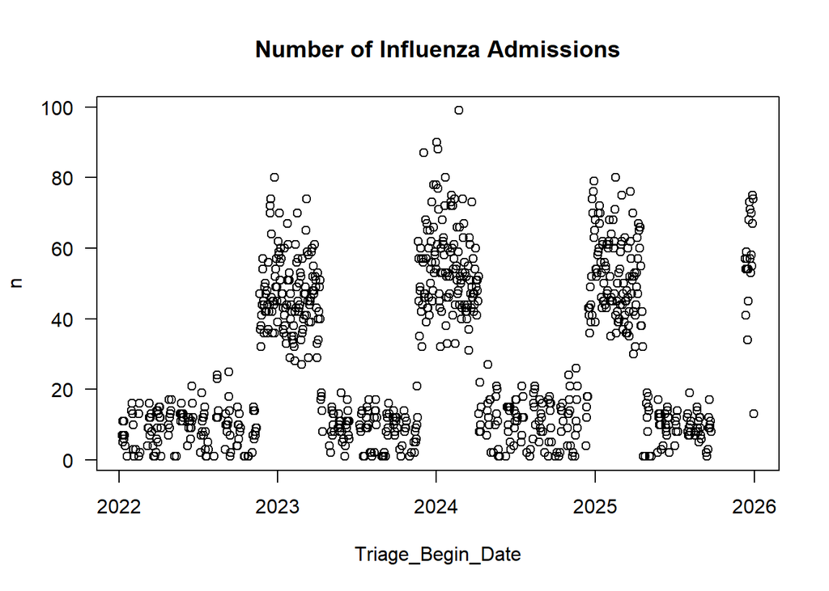

```r
filename <- "C:/Users/CNowak/OneDrive - Universität für Weiterbildung Krems/Beratung/2026/AlexanderBraun_20260217/"

# all_dates <- tibble(Triage_Begin_Date = seq.Date(as.Date("2022-01-01"),
#                                                  as.Date("2025-12-31"),
#                                                  by = "day"))

addVariables <- function(dat,intday="01Jan2024"){
  dat <- alldates |> left_join(dat,by=c("Triage_Begin_Date",
                                        "Day",
                                        "Month",
                                        "Year",
                                        "Week_Day"))
  dat <- dat |> mutate(
                Triage_Begin_Day=as.integer(Triage_Begin_Date - min(Triage_Begin_Date)) + 1,
                Interruption_Day=as.integer(as.Date(x=intday,"%d%b%Y") - min(Triage_Begin_Date)) + 1,
                Level_Change=ifelse(Triage_Begin_Day < Interruption_Day,0,1),
                Slope_Change=ifelse(Level_Change==0,0,Triage_Begin_Day-Interruption_Day), #01Jan2024 equals Triage_Begin_Day 731
                n=ifelse(is.na(n),0,n),
                .after=1)
  return(dat)
}

addVariables2 <- function(dat,intday="01Jan2024"){
  dat <- dat |> mutate(
                Triage_Begin_Month=as.integer(interval(min(Triage_Begin_Date),Triage_Begin_Date) %/% months(1)) + 1,
                Interruption_Month=as.integer(interval(min(Triage_Begin_Date),as.Date(x=intday,"%d%b%Y")) %/% months(1)) + 1,
                Level_Change=ifelse(Triage_Begin_Month < Interruption_Month,0,1),
                Slope_Change=ifelse(Level_Change==0,0,Triage_Begin_Month-Interruption_Month),
                n=ifelse(is.na(n),0,n),
                .after=1)
  return(dat)
}

weekdaylevels <- c("Mon","Tue","Wed","Thu","Fri","Sat","Sun")

holidays <- read_xlsx(str_c(filename,"Feiertage_AT_Taggenau_2022_2025.xlsx")) |>
            mutate(Triage_Begin_Date=as_date(dmy(Datum)),
                   Holiday=ifelse(Feiertag==TRUE,1,0)) |>
            dplyr::select(Triage_Begin_Date,Holiday)

dat00 <- read_xlsx(str_c(filename,"MTS Daten_2022-2025_complete.xlsx"),
                   range="A1:M84739",
                   sheet="Daten2022-2025") |>
         mutate(Triage_Begin_Date=as_date(Triage_Begin), .after=1) |>
         distinct() |>
           mutate(WD = recode(Week_Day,"Mo" = "Mon",
                                       "Di" = "Tue",
                                       "Mi" = "Wed",
                                       "Do" = "Thu",
                                       "Fr" = "Fri",
                                       "Sa" = "Sat",
                                       "So" = "Sun"),
                  WD = fct_relevel(WD,weekdaylevels),
                  WD2 = ifelse(WD=="Tue",1,0),
                  WD3 = ifelse(WD=="Wed",1,0),
                  WD4 = ifelse(WD=="Thu",1,0),
                  WD5 = ifelse(WD=="Fri",1,0),
                  WD6 = ifelse(WD=="Sat",1,0),
                  WD7 = ifelse(WD=="Sun",1,0)) |>
          left_join(holidays,by="Triage_Begin_Date")



alldates <- dat00 |> group_by(Triage_Begin_Date,Day,Month,Year,
                              Week_Day) |>
            count() |> ungroup() |>
            dplyr::select(-n)


influenz <- dat00 |> dplyr::select(Triage_Begin_Date,Influenza) |>
            filter(Influenza=="ja") |> count(Triage_Begin_Date)

plot(influenz,las=1,main="Number of Influenza Admissions")
```

```r
influenz |> filter(n>=30) |>
            mutate(next_date = lead(Triage_Begin_Date),
                   gap = as.integer(next_date - Triage_Begin_Date)) |>
            filter(gap >= 2)
```

| Triage_Begin_Date | n | next_date | gap |
| --- | --- | --- | --- |
| 2023-01-28 | 51 | 2023-01-30 | 2 |
| 2023-02-08 | 32 | 2023-02-10 | 2 |
| 2023-02-24 | 52 | 2023-02-26 | 2 |
| 2023-03-11 | 45 | 2023-03-13 | 2 |
| 2023-04-01 | 33 | 2023-04-03 | 2 |
| 2023-04-09 | 51 | 2023-11-20 | 225 |
| 2024-04-07 | 52 | 2024-12-16 | 253 |
| 2025-04-20 | 32 | 2025-12-11 | 235 |

```r
influenz |> filter(n>=30) |>
            summarise(season1_start=min(Triage_Begin_Date),
                      season4_end=max(Triage_Begin_Date))
```

| season1_start | season4_end |
| --- | --- |
| 2022-11-21 | 2025-12-30 |

```r
alldates <- alldates |>
  mutate(season1=as.integer(Triage_Begin_Date >= as.Date("2022-11-21") & Triage_Begin_Date <= as.Date("2023-04-09")),
         season2=as.integer(Triage_Begin_Date >= as.Date("2023-11-20") & Triage_Begin_Date <= as.Date("2024-04-07")),
         season3=as.integer(Triage_Begin_Date >= as.Date("2024-12-16") & Triage_Begin_Date <= as.Date("2025-04-20")),
         season4=as.integer(Triage_Begin_Date >= as.Date("2025-12-11") & Triage_Begin_Date <= as.Date("2025-12-31")),
         influenza=season1+season2+season3+season4) |>
  dplyr::select(-c(season1,season2,season3,season4))
```

Based on this data set I extracted the following dates for the influenza season:

| Influenza | Start Date | End Date |
| --- | --- | --- |
| Season 1 | 2022-11-21 | 2023-04-09 |
| Season 2 | 2023-11-20 | 2024-04-07 |
| Season 3 | 2024-12-16 | 2025-04-20 |
| Season 4 | 2025-12-11 | 2025-12-31 |

# How do I get daily and monthy admissions before and after the opening of the PHC?

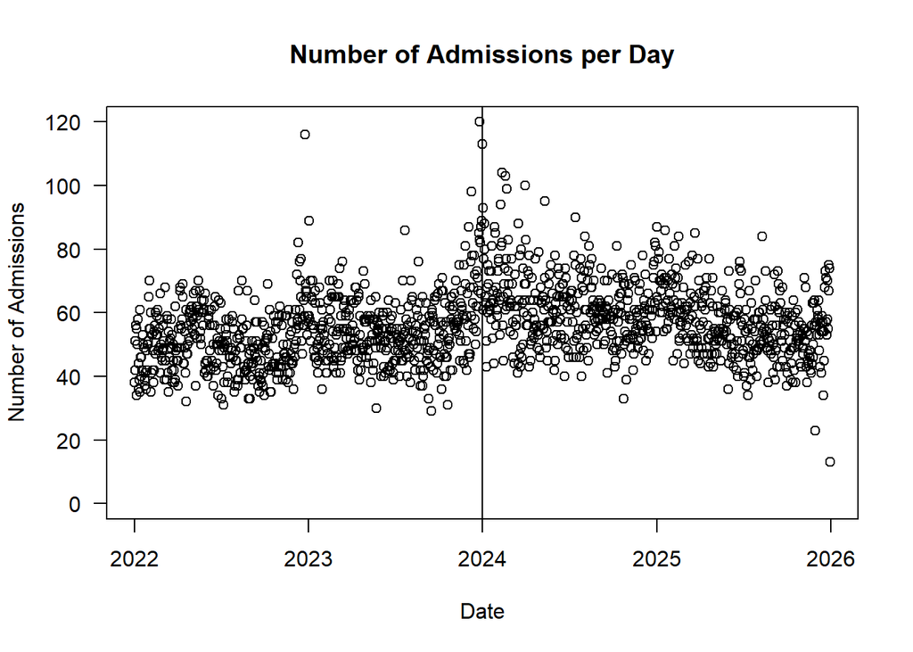

```r
daily <- dat00 |>
         group_by(Triage_Begin_Date,Day,Month,Year,Week_Day,WD) |>
         count() |>
         mutate(PreInterruption = ifelse(Triage_Begin_Date < as.Date(x="01Jan2024","%d%b%Y"),0,1))


plot(daily$Triage_Begin_Date,daily$n,
     ylim=c(0,120),
     las=1,
     ylab="Number of Admissions",
     #type="l",
     xlab="Date",
     main="Number of Admissions per Day")
abline(v=as.Date(x="01Jan2024","%d%b%Y"))
```

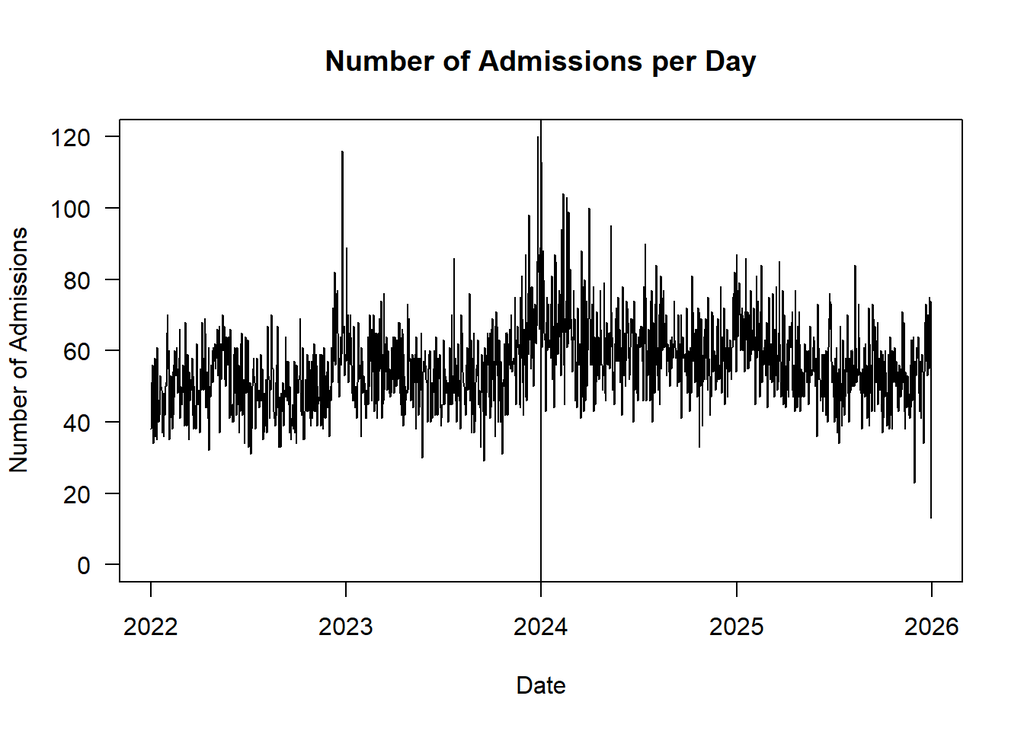

```r
plot(daily$Triage_Begin_Date,daily$n,
     ylim=c(0,120),
     las=1,
     ylab="Number of Admissions",
     type="l",
     xlab="Date",
     main="Number of Admissions per Day")
abline(v=as.Date(x="01Jan2024","%d%b%Y"))
```

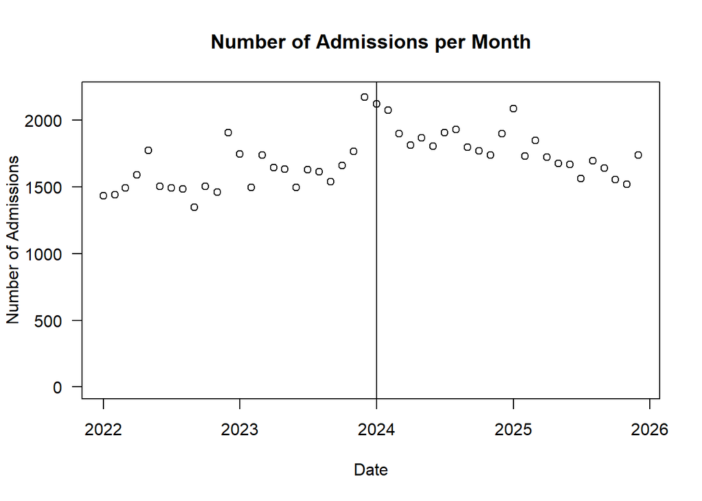

```r
monthly <- dat00 |>
           mutate(Triage_Begin_ym=format(Triage_Begin, "%Y-%m"),
                  Triage_Begin_ymf=floor_date(Triage_Begin_Date,unit="month"),.after=2) |>
           group_by(Year,Triage_Begin_ymf) |>
           count() |>
           mutate(PreInterruption = ifelse(Triage_Begin_ymf < as.Date(x="01Jan2024","%d%b%Y"),0,1))

# monthly2<- dat00 |>
#            mutate(Triage_Begin_ym=format(Triage_Begin, "%Y-%m"),
#                   Triage_Begin_ymf=floor_date(Triage_Begin_Date,unit="month"),.after=2) |>
#            group_by(Year,Triage_Begin_ymf,WD) |>
#            count() |>
#            mutate(PreInterruption = ifelse(Triage_Begin_ymf < as.Date(x="01Jan2024","%d%b%Y"),0,1))

yearly <-  dat00 |>
           group_by(Year) |>
           count()

yearly2 <- dat00 |>
           group_by(Year,WD) |>
           count()

plot(monthly$Triage_Begin_ymf,monthly$n,
     ylim=c(0,2200),
     las=1,
     ylab="Number of Admissions",
     #type="l",
     xlab="Date",
     main="Number of Admissions per Month")
abline(v=as.Date(x="01Jan2024","%d%b%Y"))
```

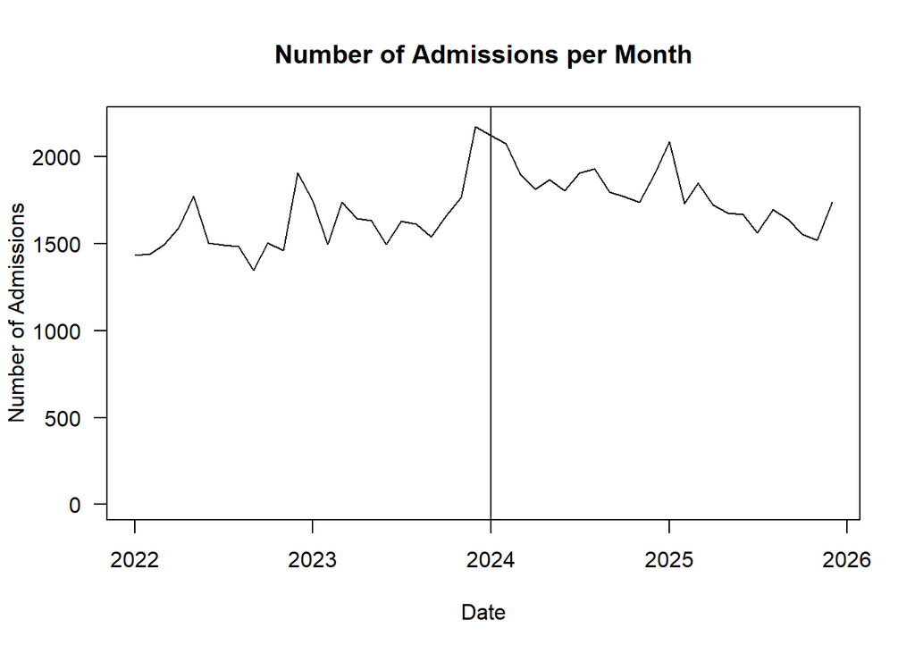

```r
plot(monthly$Triage_Begin_ymf,monthly$n,
     ylim=c(0,2200),
     las=1,
     ylab="Number of Admissions",
     type="l",
     xlab="Date",
     main="Number of Admissions per Month")
abline(v=as.Date(x="01Jan2024","%d%b%Y"))
```

```r
desdaily <- daily |> group_by(PreInterruption) |>
                     summarise(mean=mean(n),
                               sd=sd(n),
                               n=n())

desdaily2  <- daily |> group_by(PreInterruption,WD) |>
                       summarise(mean=mean(n),
                                 sd=sd(n),
                                 n=n())
```

```
`summarise()` has regrouped the output.
ℹ Summaries were computed grouped by PreInterruption and WD.
ℹ Output is grouped by PreInterruption.
ℹ Use `summarise(.groups = "drop_last")` to silence this message.
ℹ Use `summarise(.by = c(PreInterruption, WD))` for per-operation grouping
  (`?dplyr::dplyr_by`) instead.
```

```r
desdaily3  <- dat00 |> group_by(Triage_Begin_Date,Day,Month,Year,Week_Day,WD,PVE_Open) |>
                       count() |>
                       mutate(PreInterruption = ifelse(Triage_Begin_Date < as.Date(x="01Jan2024","%d%b%Y"),0,1)) |>
                       group_by(PreInterruption,WD,PVE_Open) |>
                       summarise(mean=mean(n),
                                 sd=sd(n),
                                 n=n())
```

```
`summarise()` has regrouped the output.
ℹ Summaries were computed grouped by PreInterruption, WD, and PVE_Open.
ℹ Output is grouped by PreInterruption and WD.
ℹ Use `summarise(.groups = "drop_last")` to silence this message.
ℹ Use `summarise(.by = c(PreInterruption, WD, PVE_Open))` for per-operation
  grouping (`?dplyr::dplyr_by`) instead.
```

```r
desmonthly <- monthly |> group_by(PreInterruption) |>
                         summarise(mean=mean(n),
                         sd=sd(n),
                         n=n())


desdaily
```

| PreInterruption | mean | sd | n |
| --- | --- | --- | --- |
| 0 | 52.85479 | 10.74218 | 730 |
| 1 | 58.94254 | 11.42849 | 731 |

```r
desmonthly
```

| PreInterruption | mean | sd | n |
| --- | --- | --- | --- |
| 0 | 1607.667 | 179.6421 | 24 |
| 1 | 1795.292 | 161.4619 | 24 |

```r
yearly
```

| Year | n |
| --- | --- |
| 2022 | 18439 |
| 2023 | 20145 |
| 2024 | 22632 |
| 2025 | 20455 |

```r
(desdaily$mean[2]-desdaily$mean[1])/desdaily$mean[1]*100 # change in percent
```

```
[1] 11.51788
```

```r
(desmonthly$mean[2]-desmonthly$mean[1])/desmonthly$mean[1]*100 # change in percent
```

```
[1] 11.67064
```

```r
desdaily2
```

| PreInterruption | WD | mean | sd | n |
| --- | --- | --- | --- | --- |
| 0 | Mon | 57.66346 | 9.359706 | 104 |
| 0 | Tue | 52.31731 | 10.908502 | 104 |
| 0 | Wed | 52.09615 | 9.597248 | 104 |
| 0 | Thu | 51.47115 | 9.876870 | 104 |
| 0 | Fri | 52.94231 | 9.466166 | 104 |
| 0 | Sat | 50.17143 | 10.122763 | 105 |
| 0 | Sun | 53.34286 | 13.848652 | 105 |
| 1 | Mon | 65.06667 | 10.216189 | 105 |
| 1 | Tue | 55.85714 | 9.381271 | 105 |
| 1 | Wed | 55.30476 | 10.504691 | 105 |

[output cut: 4 more lines]

```r
yearly2
```

| Year | WD | n |
| --- | --- | --- |
| 2022 | Mon | 2850 |
| 2022 | Tue | 2623 |
| 2022 | Wed | 2637 |
| 2022 | Thu | 2634 |
| 2022 | Fri | 2649 |
| 2022 | Sat | 2512 |
| 2022 | Sun | 2534 |
| 2023 | Mon | 3147 |
| 2023 | Tue | 2818 |
| 2023 | Wed | 2781 |

[output cut: 18 more lines]

```r
desdaily3
```

| PreInterruption | WD | PVE_Open | mean | sd | n |
| --- | --- | --- | --- | --- | --- |
| 0 | Mon | NA | 57.66346 | 9.359706 | 104 |
| 0 | Tue | NA | 52.31731 | 10.908502 | 104 |
| 0 | Wed | NA | 52.09615 | 9.597248 | 104 |
| 0 | Thu | NA | 51.47115 | 9.876870 | 104 |
| 0 | Fri | NA | 52.94231 | 9.466166 | 104 |
| 0 | Sat | NA | 50.17143 | 10.122763 | 105 |
| 0 | Sun | NA | 53.34286 | 13.848652 | 105 |
| 1 | Mon | TRUE | 46.75238 | 8.075105 | 105 |
| 1 | Mon | NA | 18.31429 | 4.921136 | 105 |
| 1 | Tue | TRUE | 39.29524 | 7.764470 | 105 |

[output cut: 9 more lines]

# How do I get additional results for the manuscript from 08-Apr-2026?

```r
dat00 |> dplyr::select(Year,Patient_Age) |>
         group_by(Year) |>
         summarize(mean=mean(Patient_Age,na.rm=T),
                   sd=sd(Patient_Age,na.rm=T))
```

| Year | mean | sd |
| --- | --- | --- |
| 2022 | 56.51495 | 25.17057 |
| 2023 | 57.54291 | 23.23718 |
| 2024 | 58.83342 | 20.73763 |
| 2025 | 61.45989 | 19.11766 |

```r
dat00 |> group_by(Year) |>
         count(Prio) |>
         mutate(Percent=round(n/sum(n)*100,2))
```

| Year | Prio | n | Percent |
| --- | --- | --- | --- |
| 2022 | 1 | 66 | 0.36 |
| 2022 | 2 | 2086 | 11.31 |
| 2022 | 3 | 6715 | 36.42 |
| 2022 | 4 | 8396 | 45.53 |
| 2022 | 5 | 1176 | 6.38 |
| 2023 | 1 | 49 | 0.24 |
| 2023 | 2 | 2120 | 10.52 |
| 2023 | 3 | 8079 | 40.10 |
| 2023 | 4 | 8920 | 44.28 |
| 2023 | 5 | 977 | 4.85 |

[output cut: 10 more lines]

# How do I get the data sets for the analyses?

```r
datall<- dat00 |>
         group_by(Triage_Begin_Date,Day,Month,Year,Week_Day) |>
         count() |> ungroup() |> addVariables()

datalld<-dat00 |>
         group_by(Triage_Begin_Date,Day,Month,Year,Week_Day) |>
         count() |> ungroup() |> addVariables(intday="01Dec2023")

datallf<-dat00 |>
         group_by(Triage_Begin_Date,Day,Month,Year,Week_Day) |>
         count() |> ungroup() |> addVariables(intday="01Feb2024")

datall5<-dat00 |>
         group_by(Triage_Begin_Date,Day,Month,Year,Week_Day) |>
         count() |> ungroup() |> addVariables(intday="01Jan2025")

datallm<-dat00 |>
         mutate(Triage_Begin_Date = floor_date(Triage_Begin_Date,"month")) |>
         dplyr::select(Triage_Begin_Date,Month,Year) |>
         group_by(Triage_Begin_Date,Month,Year) |>
         count() |> ungroup() |> addVariables2(intday="01Jan2024")

####### Subgroup analyses ######
datsem<- dat00 |> filter(Patient_Sex=="M") |>
         group_by(Triage_Begin_Date,Day,Month,Year,Week_Day) |>
         count() |> ungroup() |> addVariables()

datsef<- dat00 |> filter(Patient_Sex=="W") |>
         group_by(Triage_Begin_Date,Day,Month,Year,Week_Day) |>
         count() |> ungroup() |> addVariables()

datag12<-dat00 |>  filter(Patient_Age_Category %in% c("1","2")) |>
         group_by(Triage_Begin_Date,Day,Month,Year,Week_Day) |>
         count() |> ungroup() |> addVariables()

datag3<- dat00 |>  filter(Patient_Age_Category=="3") |>
         group_by(Triage_Begin_Date,Day,Month,Year,Week_Day) |>
         count() |> ungroup() |> addVariables()

datag4<- dat00 |>  filter(Patient_Age_Category=="4") |>
         group_by(Triage_Begin_Date,Day,Month,Year,Week_Day) |>
         count() |> ungroup() |> addVariables()

datag5<- dat00 |>  filter(Patient_Age_Category=="5") |>
         group_by(Triage_Begin_Date,Day,Month,Year,Week_Day) |>
         count() |> ungroup() |> addVariables()

datpr12<-dat00 |>  filter(Prio %in% c("1","2")) |>
         group_by(Triage_Begin_Date,Day,Month,Year,Week_Day) |>
         count() |> ungroup() |> addVariables()

datpr3<- dat00 |>  filter(Prio=="3") |>
         group_by(Triage_Begin_Date,Day,Month,Year,Week_Day) |>
         count() |> ungroup() |> addVariables()

datpr45<-dat00 |>  filter(Prio %in% c("4","5")) |>
         group_by(Triage_Begin_Date,Day,Month,Year,Week_Day) |>
         count() |> ungroup() |> addVariables()

##### Add subgroup analyses for reviewer #####
datwk  <-dat00 |>  filter(WD %in% c("Mon","Tue","Wed","Thu","Fri")) |>
         group_by(Triage_Begin_Date,Day,Month,Year,Week_Day,WD) |>
         count() |> ungroup() |> addVariables() |>
         filter(!is.na(WD))

datss  <-dat00 |>  filter(WD %in% c("Sat","Sun")) |>
         group_by(Triage_Begin_Date,Day,Month,Year,Week_Day,WD) |>
         count() |> ungroup() |> addVariables() |>
         filter(!is.na(WD))

datop  <-dat00 |>  filter(PVE_Open==TRUE) |>
         group_by(Triage_Begin_Date,Day,Month,Year,Week_Day,WD) |>
         count() |> ungroup() |> addVariables() |>
         filter(!is.na(WD))

datopn <-dat00 |>  filter(is.na(PVE_Open)) |>
         group_by(Triage_Begin_Date,Day,Month,Year,Week_Day,WD) |>
         count() |> ungroup() |> addVariables() |>
         filter(Level_Change==1)

##### Add analyses for reviewer comments from 22-Jun-2026 #####
datnew <- dat00 |>
          group_by(Triage_Begin_Date,Day,Month,Year,Week_Day,Holiday,WD2,WD3,WD4,WD5,WD6,WD7) |>
          count() |> ungroup() |> addVariables()
```

## Which function do I write to perform the segmented regression analysis as suggested by Korevaar et al.?

```r
getITSresults <- function(dat0,outcome,ptitle,intday="01Jan2024"){
  form <- formula(paste0(outcome, " ~ Triage_Begin_Day + Level_Change + Slope_Change",sep=""))
  print(form)
  REML_model <- gls(model=form,
                    method="REML",
                    corr=corAR1(form=~Triage_Begin_Day),
                    data=dat0
  )
  # print the results of the analysis to the console
  print(summary(REML_model)) # display the parameter estimates

  # to save the parameter estimates:
  # predicted values
  model_estimates <- REML_model$fitted
  # save the parameter estimates for display in graphs etc.
  model_intercept <- REML_model$coefficients[1]
  model_pre_slope <- REML_model$coefficients[2]
  model_level_change <- REML_model$coefficients[3]
  model_slope_change <- REML_model$coefficients[4]
  # generate the confidence intervals
  model_CIs <- confint(REML_model)
  # display the confidence intervals in the console
  print("Below are the model estimates together with their 95% confidence limits.")
  print(cbind(`Point estimates`=c(model_intercept,
                                  model_pre_slope,
                                  model_level_change,
                                  model_slope_change),
              model_CIs))
  # save the CIs for display in graphs etc.
  ####
  print("Below are the model estimates together with multiplicity adjusted p-values and confidence limits")
  set.seed(12345)
  REML_modelg <- glht(REML_model)
  print(summary(REML_modelg))
  print(confint(REML_modelg))
  ## outputs Alex:
  model_n   <- REML_model$dims$N
  ss        <- summary(REML_model)
  model_AIC <- ss$AIC
  model_BIC <- ss$BIC
  print("Below is the output requested by Alexander Braun")
  print(round(t(data.frame(model_intercept=model_intercept,
                model_pre_slope=model_pre_slope,
                model_level_change=model_level_change,
                model_slope_change=model_slope_change,
                model_AIC=model_AIC,
                model_BIC=model_BIC,
                model_n=model_n)),5))
  #####################
  ### Create a plot ###
  #####################
  dat0$prediction <- predict(REML_model)

  # create the counterfactual data, recall this is what would have happened had there been no interruption
  # and therefore is simple to generate by just using the intercept and pre_slope data
  dat0$counterfactual <- model_intercept + model_pre_slope*dat0$Triage_Begin_Day

  # for the graph we need the interruption time
  int_time <- as.Date(x=intday,"%d%b%Y")

  # colourblind colour blue
  myblue <- rgb(0,114,178,max=255,alpha=255)
  myothe <- rgb(248,118,109,max=255,alpha=255)

  # legends can be tricky, I found this useful... https://stackoverflow.com/questions/17148679/construct-a-manual-legend-for-a-complicated-plot
  # set the colours to be used
  colors <- c("Trend lines"=myblue,"Counterfactual"=myblue,"Data points"=myblue)
  # set the line types (the lty values)
  line_types <- c("Trend lines"=1,"Counterfactual"=2)

  # set up the plot
  ITS_plot <- ggplot(data=dat0,aes(x=Triage_Begin_Date,y=!!sym(outcome))) +
    # add the actual data points
    geom_point(color="black", pch=1, size=1, stroke=1) +
    # set the predicted line in the pre-interruption segment
    geom_line(data=subset(dat0,Level_Change==0), aes(x=Triage_Begin_Date,y=prediction,color="Trend lines",linetype="Trend lines"), lwd=2) +
    # set the predicted line in the post-interruption segment
    geom_line(data=subset(dat0,Level_Change==1), aes(x=Triage_Begin_Date,y=prediction,color="Trend lines",linetype="Trend lines"), lwd=2) +
    # set the counterfactual line in the post-interruption segment
    geom_line(data=subset(dat0,Level_Change==1), aes(x=Triage_Begin_Date,y=counterfactual,color="Counterfactual",linetype="Counterfactual"), lwd=2) +
    # add some labels to the axes
    labs(x="Date",y="Number of Admissions per Day",title=ptitle) +
    scale_y_continuous(limits = c(0, 120)) +
    # set the colours to be used using the vector we set up above
    scale_color_manual(name="Legend:",values=c(myothe,myblue)) +
    # set up the line types using the vector we set up above
    scale_linetype_manual(name="Legend:",values=line_types) +
    # add a vertical line for the interruption time
    geom_vline(xintercept=int_time, color="black", lty="dashed", lwd=2) +
    theme(legend.position = "bottom",
          #legend.background = element_rect(fill="white",linewidth=1,linetype="solid"),
          #legend.title = element_text(size=15),
          #legend.text = element_text(size=15),
          #legend.key.width = unit(4,"cm"),
          #legend.key = element_rect(colour=NA, fill=NA),
          #panel.background = element_blank(),
          #panel.grid.major = element_line(colour="gray"),
          #axis.title.y = element_text(face="bold", size=20),
          #axis.title.x = element_text(face="bold", size=20),
          #plot.title = element_text(face="bold", size=20),
          #axis.text.x=element_text(face="bold", size=15),
          #axis.text.y=element_text(face="bold", size=15),
    )
  # show this plot in the plots window
  ITS_plot
}
###
###
###
getITSresultsMonth <- function(dat0,outcome,ptitle,intday="01Jan2024"){
  form <- formula(paste0(outcome, " ~ Triage_Begin_Month + Level_Change + Slope_Change",sep=""))
  print(form)
  REML_model <- gls(model=form,
                    method="REML",
                    corr=corAR1(form=~Triage_Begin_Month),
                    data=dat0
  )
  # print the results of the analysis to the console
  print(summary(REML_model)) # display the parameter estimates

  # to save the parameter estimates:
  # predicted values
  model_estimates <- REML_model$fitted
  # save the parameter estimates for display in graphs etc.
  model_intercept <- REML_model$coefficients[1]
  model_pre_slope <- REML_model$coefficients[2]
  model_level_change <- REML_model$coefficients[3]
  model_slope_change <- REML_model$coefficients[4]
  # generate the confidence intervals
  model_CIs <- confint(REML_model)
  # display the confidence intervals in the console
  print("Below are the model estimates together with their 95% confidence limits.")
  print(cbind(`Point estimates`=c(model_intercept,
                                  model_pre_slope,
                                  model_level_change,
                                  model_slope_change),
              model_CIs))
  # save the CIs for display in graphs etc.
  ####
  print("Below are the model estimates together with multiplicity adjusted p-values and confidence limits")
  set.seed(12345)
  REML_modelg <- glht(REML_model)
  print(summary(REML_modelg))
  print(confint(REML_modelg))
  ## outputs Alex:
  model_n   <- REML_model$dims$N
  ss        <- summary(REML_model)
  model_AIC <- ss$AIC
  model_BIC <- ss$BIC
  print("Below is the output requested by Alexander Braun")
  print(round(t(data.frame(model_intercept=model_intercept,
                model_pre_slope=model_pre_slope,
                model_level_change=model_level_change,
                model_slope_change=model_slope_change,
                model_AIC=model_AIC,
                model_BIC=model_BIC,
                model_n=model_n)),5))
  #####################
  ### Create a plot ###
  #####################
  dat0$prediction <- predict(REML_model)
```

```r
  # create the counterfactual data, recall this is what would have happened had there been no interruption
  # and therefore is simple to generate by just using the intercept and pre_slope data
  dat0$counterfactual <- model_intercept + model_pre_slope*dat0$Triage_Begin_Month

  # for the graph we need the interruption time
  int_time <- as.Date(x=intday,"%d%b%Y")

  # colourblind colour blue
  myblue <- rgb(0,114,178,max=255,alpha=255)
  myothe <- rgb(248,118,109,max=255,alpha=255)

  # legends can be tricky, I found this useful... https://stackoverflow.com/questions/17148679/construct-a-manual-legend-for-a-complicated-plot
  # set the colours to be used
  colors <- c("Trend lines"=myblue,"Counterfactual"=myblue,"Data points"=myblue)
  # set the line types (the lty values)
  line_types <- c("Trend lines"=1,"Counterfactual"=2)

  # set up the plot
  ITS_plot <- ggplot(data=dat0,aes(x=Triage_Begin_Date,y=!!sym(outcome))) +
    # add the actual data points
    geom_point(color="black", pch=1, size=1, stroke=1) +
    # set the predicted line in the pre-interruption segment
    geom_line(data=subset(dat0,Level_Change==0), aes(x=Triage_Begin_Date,y=prediction,color="Trend lines",linetype="Trend lines"), lwd=2) +
    # set the predicted line in the post-interruption segment
    geom_line(data=subset(dat0,Level_Change==1), aes(x=Triage_Begin_Date,y=prediction,color="Trend lines",linetype="Trend lines"), lwd=2) +
    # set the counterfactual line in the post-interruption segment
    geom_line(data=subset(dat0,Level_Change==1), aes(x=Triage_Begin_Date,y=counterfactual,color="Counterfactual",linetype="Counterfactual"), lwd=2) +
    # add some labels to the axes
    labs(x="Date",y="Number of Admissions per Month",title=ptitle) +
    scale_y_continuous(limits = c(0, 2200)) +
    # set the colours to be used using the vector we set up above
    scale_color_manual(name="Legend:",values=c(myothe,myblue)) +
    # set up the line types using the vector we set up above
    scale_linetype_manual(name="Legend:",values=line_types) +
    # add a vertical line for the interruption time
    geom_vline(xintercept=int_time, color="black", lty="dashed", lwd=2) +
    theme(legend.position = "bottom",
          #legend.background = element_rect(fill="white",linewidth=1,linetype="solid"),
          #legend.title = element_text(size=15),
          #legend.text = element_text(size=15),
          #legend.key.width = unit(4,"cm"),
          #legend.key = element_rect(colour=NA, fill=NA),
          #panel.background = element_blank(),
          #panel.grid.major = element_line(colour="gray"),
          #axis.title.y = element_text(face="bold", size=20),
          #axis.title.x = element_text(face="bold", size=20),
          #plot.title = element_text(face="bold", size=20),
          #axis.text.x=element_text(face="bold", size=15),
          #axis.text.y=element_text(face="bold", size=15),
    )
  # show this plot in the plots window
  ITS_plot
}





###
getITSresultsInf <- function(dat0,outcome,ptitle,intday="01Jan2024"){
  form <- formula(paste0(outcome, " ~ Triage_Begin_Day + Level_Change + Slope_Change + influenza",sep=""))
  print(form)
  REML_model <- gls(model=form,
                    method="REML",
                    corr=corAR1(form=~Triage_Begin_Day),
                    #corr=corARMA(form=~Triage_Begin_Day,p=1,q=1),
                    data=dat0
  )
  # print the results of the analysis to the console
  print(summary(REML_model)) # display the parameter estimates

  # to save the parameter estimates:
  # predicted values
  model_estimates <- REML_model$fitted
  # save the parameter estimates for display in graphs etc.
  model_intercept <- REML_model$coefficients[1]
  model_pre_slope <- REML_model$coefficients[2]
  model_level_change <- REML_model$coefficients[3]
  model_slope_change <- REML_model$coefficients[4]
  model_influenza <- REML_model$coefficients[5]
  # generate the confidence intervals
  model_CIs <- confint(REML_model)
  # display the confidence intervals in the console
  print("Below are the model estimates together with their 95% confidence limits.")
  print(cbind(`Point estimates`=c(model_intercept,
                                  model_pre_slope,
                                  model_level_change,
                                  model_slope_change,
                                  model_influenza),
               model_CIs))
  ###
  print("Below are the model estimates together with multiplicity adjusted p-values and confidence limits")
  set.seed(12345)
  REML_modelg <- glht(REML_model)
  print(summary(REML_modelg))
  print(confint(REML_modelg))
  ## outputs Alex:
  model_n   <- REML_model$dims$N
  ss        <- summary(REML_model)
  model_AIC <- ss$AIC
  model_BIC <- ss$BIC
  print("Below is the output requested by Alexander Braun")
  print(round(t(data.frame(model_intercept=model_intercept,
                model_pre_slope=model_pre_slope,
                model_level_change=model_level_change,
                model_slope_change=model_slope_change,
                model_influenza=model_influenza,
                model_AIC=model_AIC,
                model_BIC=model_BIC,
                model_n=model_n)),5))

  #####################
  ### Create a plot ###
  #####################
  dat0$prediction <- predict(REML_model)

  # create the counterfactual data, recall this is what would have happened had there been no interruption
  # and therefore is simple to generate by just using the intercept and pre_slope data
  dat0$counterfactual <- model_intercept + model_pre_slope*dat0$Triage_Begin_Day + model_influenza*dat0$influenza

  # for the graph we need the interruption time
  int_time <- as.Date(x=intday,"%d%b%Y")


  # colourblind colour blue
  myblue <- rgb(0,114,178,max=255,alpha=255)
  myothe <- rgb(248,118,109,max=255,alpha=255)

  # legends can be tricky, I found this useful... https://stackoverflow.com/questions/17148679/construct-a-manual-legend-for-a-complicated-plot
  # set the colours to be used
  colors <- c("Trend lines"=myblue,"Counterfactual"=myblue,"Data points"=myblue)
  # set the line types (the lty values)
  line_types <- c("Trend lines"=1,"Counterfactual"=2)
```

```r
  # set up the plot
  ITS_plot <- ggplot(data=dat0,aes(x=Triage_Begin_Date,y=!!sym(outcome))) +
    # add the actual data points
    geom_point(color="black", pch=1, size=1, stroke=1) +
    # set the predicted line in the pre-interruption segment
    geom_line(data=subset(dat0,Level_Change==0), aes(x=Triage_Begin_Date,y=prediction,color="Trend lines",linetype="Trend lines"), lwd=2) +
    # set the predicted line in the post-interruption segment
    geom_line(data=subset(dat0,Level_Change==1), aes(x=Triage_Begin_Date,y=prediction,color="Trend lines",linetype="Trend lines"), lwd=2) +
    # set the counterfactual line in the post-interruption segment
    geom_line(data=subset(dat0,Level_Change==1), aes(x=Triage_Begin_Date,y=counterfactual,color="Counterfactual",linetype="Counterfactual"), lwd=2) +
    # add some labels to the axes
    labs(x="Date",y="Number of Admissions per Day",title=ptitle) +
    scale_y_continuous(limits = c(0, 120)) +
    # set the colours to be used using the vector we set up above
    scale_color_manual(name="Legend:",values=c(myothe,myblue)) +
    # set up the line types using the vector we set up above
    scale_linetype_manual(name="Legend:",values=line_types) +
    # add a vertical line for the interruption time
    geom_vline(xintercept=int_time, color="black", lty="dashed", lwd=2) +
    theme(legend.position = "bottom",
          #legend.background = element_rect(fill="white",linewidth=1,linetype="solid"),
          #legend.title = element_text(size=15),
          #legend.text = element_text(size=15),
          #legend.key.width = unit(4,"cm"),
          #legend.key = element_rect(colour=NA, fill=NA),
          #panel.background = element_blank(),
          #panel.grid.major = element_line(colour="gray"),
          #axis.title.y = element_text(face="bold", size=20),
          #axis.title.x = element_text(face="bold", size=20),
          #plot.title = element_text(face="bold", size=20),
          #axis.text.x=element_text(face="bold", size=15),
          #axis.text.y=element_text(face="bold", size=15),
    )
  # show this plot in the plots window
  ITS_plot
}


getITSresultsNew <- function(dat0,outcome,ptitle,intday="01Jan2024"){
  form <- formula(paste0(outcome, " ~ Triage_Begin_Day + Level_Change + Slope_Change + influenza + Holiday + WD2 + WD3 + WD4 + WD5 + WD6 + WD7",sep=""))
  print(form)
  REML_model <- gls(model=form,
                    method="REML",
                    corr=corAR1(form=~Triage_Begin_Day),
                    #corr=corARMA(form=~Triage_Begin_Day,p=1,q=1),
                    data=dat0
  )
  # print the results of the analysis to the console
  print(summary(REML_model)) # display the parameter estimates

  # to save the parameter estimates:
  # predicted values
  model_estimates <- REML_model$fitted
  # save the parameter estimates for display in graphs etc.
  model_intercept <- REML_model$coefficients[1]
  model_pre_slope <- REML_model$coefficients[2]
  model_level_change <- REML_model$coefficients[3]
  model_slope_change <- REML_model$coefficients[4]
  model_influenza <- REML_model$coefficients[5]
  model_holiday <- REML_model$coefficients[6]
  model_WD2 <- REML_model$coefficients[7]
  model_WD3 <- REML_model$coefficients[8]
  model_WD4 <- REML_model$coefficients[9]
  model_WD5 <- REML_model$coefficients[10]
  model_WD6 <- REML_model$coefficients[11]
  model_WD7 <- REML_model$coefficients[12]

  # generate the confidence intervals
  model_CIs <- confint(REML_model)
  # display the confidence intervals in the console
  print("Below are the model estimates together with their 95% confidence limits.")
  print(cbind(`Point estimates`=c(model_intercept,
                                  model_pre_slope,
                                  model_level_change,
                                  model_slope_change,
                                  model_influenza,
                                  model_holiday,
                                  model_WD2,
                                  model_WD3,
                                  model_WD4,
                                  model_WD5,
                                  model_WD6,
                                  model_WD7),
               model_CIs))
  ###
  print("Below are the model estimates together with multiplicity adjusted p-values and confidence limits")
  set.seed(12345)
  REML_modelg <- glht(REML_model)
  print(summary(REML_modelg))
  print(confint(REML_modelg))
  ## outputs Alex:
  model_n   <- REML_model$dims$N
  ss        <- summary(REML_model)
  model_AIC <- ss$AIC
  model_BIC <- ss$BIC
  print("Below is the output requested by Alexander Braun")
  print(round(t(data.frame(model_intercept=model_intercept,
                model_pre_slope=model_pre_slope,
                model_level_change=model_level_change,
                model_slope_change=model_slope_change,
                model_influenza=model_influenza,
                model_holiday=model_holiday,
                model_WD2=model_WD2,
                model_WD3=model_WD3,
                model_WD4=model_WD4,
                model_WD5=model_WD5,
                model_WD6=model_WD6,
                model_WD7=model_WD7,
                model_AIC=model_AIC,
                model_BIC=model_BIC,
                model_n=model_n)),5))

  #####################
  ### Create a plot ###
  #####################
  dat0$prediction <- predict(REML_model)

  # create the counterfactual data, recall this is what would have happened had there been no interruption
  # and therefore is simple to generate by just using the intercept and pre_slope data
  dat0$counterfactual <- model_intercept + model_pre_slope*dat0$Triage_Begin_Day +
                         model_influenza*dat0$influenza + model_holiday*dat0$Holiday +
                         model_WD2*dat0$WD2 +
                         model_WD3*dat0$WD3 +
                         model_WD4*dat0$WD4 +
                         model_WD5*dat0$WD5 +
                         model_WD6*dat0$WD6 +
                         model_WD7*dat0$WD7
  # for the graph we need the interruption time
  int_time <- as.Date(x=intday,"%d%b%Y")
```

```r
  # colourblind colour blue
  myblue <- rgb(0,114,178,max=255,alpha=255)
  myothe <- rgb(248,118,109,max=255,alpha=255)

  # legends can be tricky, I found this useful... https://stackoverflow.com/questions/17148679/construct-a-manual-legend-for-a-complicated-plot
  # set the colours to be used
  colors <- c("Trend lines"=myblue,"Counterfactual"=myblue,"Data points"=myblue)
  # set the line types (the lty values)
  line_types <- c("Trend lines"=1,"Counterfactual"=2)

  # set up the plot
  ITS_plot <- ggplot(data=dat0,aes(x=Triage_Begin_Date,y=!!sym(outcome))) +
    # add the actual data points
    geom_point(color="black", pch=1, size=1, stroke=1) +
    # set the predicted line in the pre-interruption segment
    geom_line(data=subset(dat0,Level_Change==0), aes(x=Triage_Begin_Date,y=prediction,color="Trend lines",linetype="Trend lines"), lwd=2) +
    # set the predicted line in the post-interruption segment
    geom_line(data=subset(dat0,Level_Change==1), aes(x=Triage_Begin_Date,y=prediction,color="Trend lines",linetype="Trend lines"), lwd=2) +
    # set the counterfactual line in the post-interruption segment
    geom_line(data=subset(dat0,Level_Change==1), aes(x=Triage_Begin_Date,y=counterfactual,color="Counterfactual",linetype="Counterfactual"), lwd=2) +
    # add some labels to the axes
    labs(x="Date",y="Number of Admissions per Day",title=ptitle) +
    scale_y_continuous(limits = c(0, 120)) +
    # set the colours to be used using the vector we set up above
    scale_color_manual(name="Legend:",values=c(myothe,myblue)) +
    # set up the line types using the vector we set up above
    scale_linetype_manual(name="Legend:",values=line_types) +
    # add a vertical line for the interruption time
    geom_vline(xintercept=int_time, color="black", lty="dashed", lwd=2) +
    theme(legend.position = "bottom",
          #legend.background = element_rect(fill="white",linewidth=1,linetype="solid"),
          #legend.title = element_text(size=15),
          #legend.text = element_text(size=15),
          #legend.key.width = unit(4,"cm"),
          #legend.key = element_rect(colour=NA, fill=NA),
          #panel.background = element_blank(),
          #panel.grid.major = element_line(colour="gray"),
          #axis.title.y = element_text(face="bold", size=20),
          #axis.title.x = element_text(face="bold", size=20),
          #plot.title = element_text(face="bold", size=20),
          #axis.text.x=element_text(face="bold", size=15),
          #axis.text.y=element_text(face="bold", size=15),
    )
  # show this plot in the plots window
  ITS_plot
}



getITSresultsInfARMA11 <- function(dat0,outcome,ptitle){
  form <- formula(paste0(outcome, " ~ Triage_Begin_Day + Level_Change + Slope_Change + influenza",sep=""))
  print(form)
  REML_model <- gls(model=form,
                    method="REML",
                    #corr=corAR1(form=~Triage_Begin_Day),
                    corr=corARMA(form=~Triage_Begin_Day,p=1,q=1),
                    data=dat0
  )
  # print the results of the analysis to the console
  print(summary(REML_model)) # display the parameter estimates

  # to save the parameter estimates:
  # predicted values
  model_estimates <- REML_model$fitted
  # save the parameter estimates for display in graphs etc.
  model_intercept <- REML_model$coefficients[1]
  model_pre_slope <- REML_model$coefficients[2]
  model_level_change <- REML_model$coefficients[3]
  model_slope_change <- REML_model$coefficients[4]
  model_influenza <- REML_model$coefficients[5]
  # generate the confidence intervals
  model_CIs <- confint(REML_model)
  # display the confidence intervals in the console
  print("Below are the model estimates together with their 95% confidence limits.")
  print(cbind(`Point estimates`=c(model_intercept,
                                  model_pre_slope,
                                  model_level_change,
                                  model_slope_change,
                                  model_influenza),
               model_CIs))
  ###
  print("Below are the model estimates together with multiplicity adjusted p-values and confidence limits")
  set.seed(12345)
  REML_modelg <- glht(REML_model)
  print(summary(REML_modelg))
  print(confint(REML_modelg))
  ## outputs Alex:
  model_n   <- REML_model$dims$N
  ss        <- summary(REML_model)
  model_AIC <- ss$AIC
  model_BIC <- ss$BIC
  print("Below is the output requested by Alexander Braun")
  print(round(t(data.frame(model_intercept=model_intercept,
                model_pre_slope=model_pre_slope,
                model_level_change=model_level_change,
                model_slope_change=model_slope_change,
                model_influenza=model_influenza,
                model_AIC=model_AIC,
                model_BIC=model_BIC,
                model_n=model_n)),5))

  #####################
  ### Create a plot ###
  #####################
  dat0$prediction <- predict(REML_model)

  # create the counterfactual data, recall this is what would have happened had there been no interruption
  # and therefore is simple to generate by just using the intercept and pre_slope data
  dat0$counterfactual <- model_intercept + model_pre_slope*dat0$Triage_Begin_Day + model_influenza*dat0$influenza

  # for the graph we need the interruption time
  int_time <- as.Date(x="01Jan2024","%d%b%Y")


  # colourblind colour blue
  myblue <- rgb(0,114,178,max=255,alpha=255)
  myothe <- rgb(248,118,109,max=255,alpha=255)

  # legends can be tricky, I found this useful... https://stackoverflow.com/questions/17148679/construct-a-manual-legend-for-a-complicated-plot
  # set the colours to be used
  colors <- c("Trend lines"=myblue,"Counterfactual"=myblue,"Data points"=myblue)
  # set the line types (the lty values)
  line_types <- c("Trend lines"=1,"Counterfactual"=2)

  # set up the plot
  ITS_plot <- ggplot(data=dat0,aes(x=Triage_Begin_Date,y=!!sym(outcome))) +
    # add the actual data points
    geom_point(color="black", pch=1, size=1, stroke=1) +
    # set the predicted line in the pre-interruption segment
    geom_line(data=subset(dat0,Level_Change==0), aes(x=Triage_Begin_Date,y=prediction,color="Trend lines",linetype="Trend lines"), lwd=2) +
    # set the predicted line in the post-interruption segment
    geom_line(data=subset(dat0,Level_Change==1), aes(x=Triage_Begin_Date,y=prediction,color="Trend lines",linetype="Trend lines"), lwd=2) +
    # set the counterfactual line in the post-interruption segment
    geom_line(data=subset(dat0,Level_Change==1), aes(x=Triage_Begin_Date,y=counterfactual,color="Counterfactual",linetype="Counterfactual"), lwd=2) +
    # add some labels to the axes
    labs(x="Date",y="Number of Admissions per Day",title=ptitle) +
    scale_y_continuous(limits = c(0, 120)) +
    # set the colours to be used using the vector we set up above
    scale_color_manual(name="Legend:",values=c(myothe,myblue)) +
    # set up the line types using the vector we set up above
    scale_linetype_manual(name="Legend:",values=line_types) +
    # add a vertical line for the interruption time
    geom_vline(xintercept=int_time, color="black", lty="dashed", lwd=2) +
    theme(legend.position = "bottom",
          #legend.background = element_rect(fill="white",linewidth=1,linetype="solid"),
          #legend.title = element_text(size=15),
          #legend.text = element_text(size=15),
          #legend.key.width = unit(4,"cm"),
          #legend.key = element_rect(colour=NA, fill=NA),
          #panel.background = element_blank(),
          #panel.grid.major = element_line(colour="gray"),
          #axis.title.y = element_text(face="bold", size=20),
          #axis.title.x = element_text(face="bold", size=20),
          #plot.title = element_text(face="bold", size=20),
          #axis.text.x=element_text(face="bold", size=15),
          #axis.text.y=element_text(face="bold", size=15),
    )
  # show this plot in the plots window
  ITS_plot
}
```

```r
getITSresultsInfAR2 <- function(dat0,outcome,ptitle){
  form <- formula(paste0(outcome, " ~ Triage_Begin_Day + Level_Change + Slope_Change + influenza",sep=""))
  print(form)
  REML_model <- gls(model=form,
                    method="REML",
                    #corr=corAR1(form=~Triage_Begin_Day),
                    corr=corARMA(form=~Triage_Begin_Day,p=2,q=0),
                    data=dat0
  )
  # print the results of the analysis to the console
  print(summary(REML_model)) # display the parameter estimates

  # to save the parameter estimates:
  # predicted values
  model_estimates <- REML_model$fitted
  # save the parameter estimates for display in graphs etc.
  model_intercept <- REML_model$coefficients[1]
  model_pre_slope <- REML_model$coefficients[2]
  model_level_change <- REML_model$coefficients[3]
  model_slope_change <- REML_model$coefficients[4]
  model_influenza <- REML_model$coefficients[5]
  # generate the confidence intervals
  model_CIs <- confint(REML_model)
  # display the confidence intervals in the console
  print("Below are the model estimates together with their 95% confidence limits.")
  print(cbind(`Point estimates`=c(model_intercept,
                                  model_pre_slope,
                                  model_level_change,
                                  model_slope_change,
                                  model_influenza),
               model_CIs))
  ###
  print("Below are the model estimates together with multiplicity adjusted p-values and confidence limits")
  set.seed(12345)
  REML_modelg <- glht(REML_model)
  print(summary(REML_modelg))
  print(confint(REML_modelg))
  ## outputs Alex:
  model_n   <- REML_model$dims$N
  ss        <- summary(REML_model)
  model_AIC <- ss$AIC
  model_BIC <- ss$BIC
  print("Below is the output requested by Alexander Braun")
  print(round(t(data.frame(model_intercept=model_intercept,
                model_pre_slope=model_pre_slope,
                model_level_change=model_level_change,
                model_slope_change=model_slope_change,
                model_influenza=model_influenza,
                model_AIC=model_AIC,
                model_BIC=model_BIC,
                model_n=model_n)),5))

  #####################
  ### Create a plot ###
  #####################
  dat0$prediction <- predict(REML_model)

  # create the counterfactual data, recall this is what would have happened had there been no interruption
  # and therefore is simple to generate by just using the intercept and pre_slope data
  dat0$counterfactual <- model_intercept + model_pre_slope*dat0$Triage_Begin_Day + model_influenza*dat0$influenza

  # for the graph we need the interruption time
  int_time <- as.Date(x="01Jan2024","%d%b%Y")


  # colourblind colour blue
  myblue <- rgb(0,114,178,max=255,alpha=255)
  myothe <- rgb(248,118,109,max=255,alpha=255)

  # legends can be tricky, I found this useful... https://stackoverflow.com/questions/17148679/construct-a-manual-legend-for-a-complicated-plot
  # set the colours to be used
  colors <- c("Trend lines"=myblue,"Counterfactual"=myblue,"Data points"=myblue)
  # set the line types (the lty values)
  line_types <- c("Trend lines"=1,"Counterfactual"=2)

  # set up the plot
  ITS_plot <- ggplot(data=dat0,aes(x=Triage_Begin_Date,y=!!sym(outcome))) +
    # add the actual data points
    geom_point(color="black", pch=1, size=1, stroke=1) +
    # set the predicted line in the pre-interruption segment
    geom_line(data=subset(dat0,Level_Change==0), aes(x=Triage_Begin_Date,y=prediction,color="Trend lines",linetype="Trend lines"), lwd=2) +
    # set the predicted line in the post-interruption segment
    geom_line(data=subset(dat0,Level_Change==1), aes(x=Triage_Begin_Date,y=prediction,color="Trend lines",linetype="Trend lines"), lwd=2) +
    # set the counterfactual line in the post-interruption segment
    geom_line(data=subset(dat0,Level_Change==1), aes(x=Triage_Begin_Date,y=counterfactual,color="Counterfactual",linetype="Counterfactual"), lwd=2) +
    # add some labels to the axes
    labs(x="Date",y="Number of Admissions per Day",title=ptitle) +
    scale_y_continuous(limits = c(0, 120)) +
    # set the colours to be used using the vector we set up above
    scale_color_manual(name="Legend:",values=c(myothe,myblue)) +
    # set up the line types using the vector we set up above
    scale_linetype_manual(name="Legend:",values=line_types) +
    # add a vertical line for the interruption time
    geom_vline(xintercept=int_time, color="black", lty="dashed", lwd=2) +
    theme(legend.position = "bottom",
          #legend.background = element_rect(fill="white",linewidth=1,linetype="solid"),
          #legend.title = element_text(size=15),
          #legend.text = element_text(size=15),
          #legend.key.width = unit(4,"cm"),
          #legend.key = element_rect(colour=NA, fill=NA),
          #panel.background = element_blank(),
          #panel.grid.major = element_line(colour="gray"),
          #axis.title.y = element_text(face="bold", size=20),
          #axis.title.x = element_text(face="bold", size=20),
          #plot.title = element_text(face="bold", size=20),
          #axis.text.x=element_text(face="bold", size=15),
          #axis.text.y=element_text(face="bold", size=15),
    )
  # show this plot in the plots window
  ITS_plot
}

###

getnts <- function(dat0,ptitle){
  est_n <- msmooth(dat0$n)
  plot(dat0$Triage_Begin_Date,est_n$orig,type="l",col="gray",
       las=1,lwd=1,
       main=str_c("Nonparametric Time Series Trend Estimation\n",ptitle),
       ylab="Number of Admissions per Day",
       ylim=c(0,120),
       xlim=c(as.Date(x="01Jan2022","%d%b%Y"),
              as.Date(x="31Dec2025","%d%b%Y")),
       xlab="Date")
  points(dat0$Triage_Begin_Date,est_n$ye,type="l",col="black",lwd=2)
  #points(cbest_n$np.estim$ye.ub,type="l",col="red",lwd=2)
  #points(cbest_n$np.estim$upper,type="l",col="red",lwd=1)
  #points(cbest_n$np.estim$lower,type="l",col="red",lwd=1)
  abline(v=as.Date(x="01Jan2024","%d%b%Y"),lwd=2,lty=2)
}
```

# How do I perform the ITSA as suggested by Korevaar et al.?

```
n ~ Triage_Begin_Day + Level_Change + Slope_Change
<environment: 0x000002672d751d50>
Generalized least squares fit by REML
  Model: form
  Data: dat0
       AIC      BIC    logLik
  10980.94 11012.65 -5484.472

Correlation Structure: AR(1)
 Formula: ~Triage_Begin_Day
 Parameter estimate(s):
      Phi
0.2233564

Coefficients:
                    Value Std.Error  t-value p-value
(Intercept)      48.04890 0.9791666 49.07122       0
Triage_Begin_Day  0.01312 0.0023201  5.65330       0
Level_Change      8.47466 1.3812324  6.13558       0
Slope_Change     -0.03278 0.0032803 -9.99245       0

 Correlation:
                 (Intr) Tr_B_D Lvl_Ch
Triage_Begin_Day -0.866
Level_Change      0.354 -0.613
Slope_Change      0.613 -0.708  0.002

Standardized residuals:
        Min          Q1         Med          Q3         Max
-3.67739615 -0.68004487 -0.05619068  0.58098473  6.00039220

Residual standard error: 10.53969
Degrees of freedom: 1461 total; 1457 residual
[1] "Below are the model estimates together with their 95% confidence limits."
                 Point estimates        2.5 %      97.5 %
(Intercept)          48.04889937 46.129768071 49.96803067
Triage_Begin_Day      0.01311645  0.008569056  0.01766384
Level_Change          8.47465517  5.767489430 11.18182091
Slope_Change         -0.03277816 -0.039207418 -0.02634891
[1] "Below are the model estimates together with multiplicity adjusted p-values and confidence limits"
```

[output cut: 27 more lines]

```
                      Estimate  lwr       upr
(Intercept) == 0      48.048899 45.701000 50.396798
Triage_Begin_Day == 0  0.013116  0.007553  0.018680
Level_Change == 0      8.474655  5.162661 11.786649
Slope_Change == 0     -0.032778 -0.040644 -0.024912

[1] "Below is the output requested by Alexander Braun"
                   (Intercept)
model_intercept       48.04890
model_pre_slope        0.01312
model_level_change     8.47466
model_slope_change    -0.03278
model_AIC          10980.94304
model_BIC          11012.64785
model_n             1461.00000
```

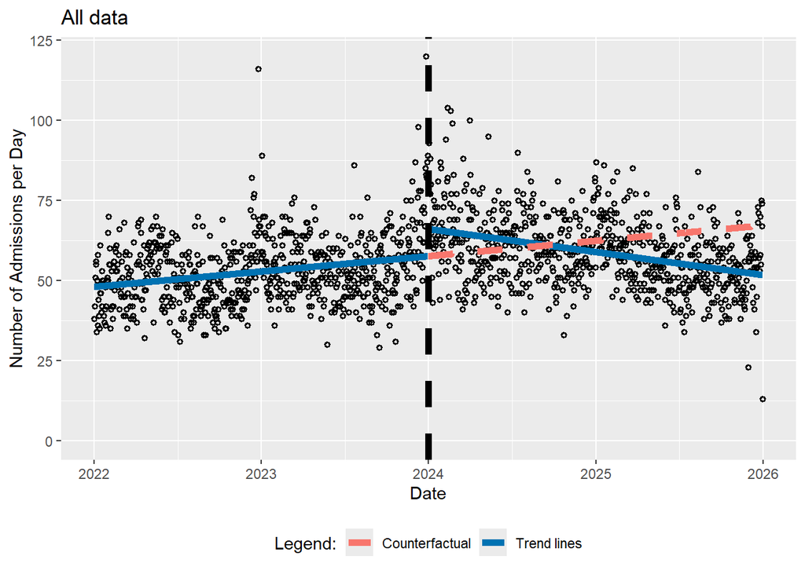

```r
getITSresults(dat0=datall,outcome="n",ptitle="All data")
```

# How do I perform the ITSA accounting for influenza?

```
n ~ Triage_Begin_Day + Level_Change + Slope_Change + influenza
<environment: 0x0000026735c1c358>
Generalized least squares fit by REML
  Model: form
  Data: dat0
       AIC      BIC    logLik
  10922.29 10959.27 -5454.144

Correlation Structure: AR(1)
 Formula: ~Triage_Begin_Day
 Parameter estimate(s):
      Phi
0.1726749

Coefficients:
                    Value Std.Error  t-value p-value
(Intercept)      47.81174 0.9015244 53.03432       0
Triage_Begin_Day  0.00979 0.0021751  4.50321       0
Level_Change      8.01940 1.2726598  6.30129       0
Slope_Change     -0.02626 0.0031236 -8.40838       0
influenza         5.83470 0.7254561  8.04281       0

 Correlation:
                 (Intr) Tr_B_D Lvl_Ch Slp_Ch
Triage_Begin_Day -0.844
Level_Change      0.355 -0.593
Slope_Change      0.584 -0.721 -0.009
influenza        -0.033 -0.191 -0.042  0.258

Standardized residuals:
        Min          Q1         Med          Q3         Max
-4.28553309 -0.70188619 -0.05811215  0.62930950  5.79696780

Residual standard error: 10.22125
Degrees of freedom: 1461 total; 1456 residual
[1] "Below are the model estimates together with their 95% confidence limits."
                 Point estimates       2.5 %      97.5 %
(Intercept)         47.811738071 46.04478269 49.57869345
Triage_Begin_Day     0.009794937  0.00553182  0.01405805
Level_Change         8.019395078  5.52502763 10.51376253
```

[output cut: 33 more lines]

```
Triage_Begin_Day == 0  0.009795  0.004344  0.015246
Level_Change == 0      8.019395  4.829952 11.208838
Slope_Change == 0     -0.026264 -0.034092 -0.018436
influenza == 0         5.834705  4.016622  7.652787

[1] "Below is the output requested by Alexander Braun"
                   (Intercept)
model_intercept       47.81174
model_pre_slope        0.00979
model_level_change     8.01940
model_slope_change    -0.02626
model_influenza        5.83470
model_AIC          10922.28704
model_BIC          10959.27118
model_n             1461.00000
```

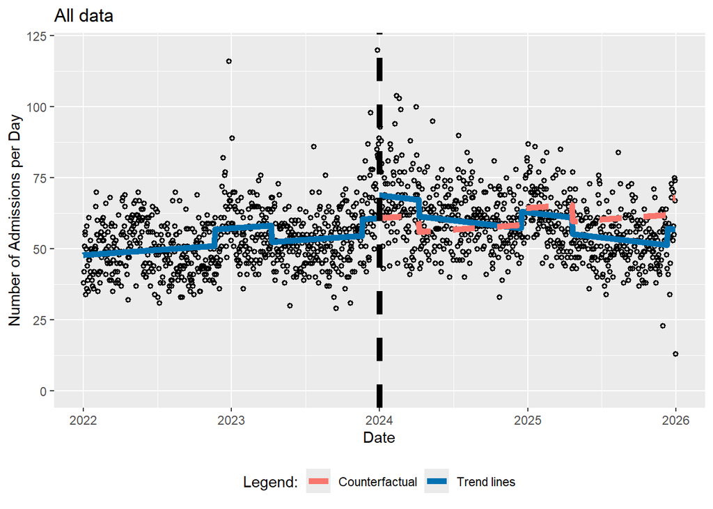

```r
getITSresultsInf(dat0=datall,outcome="n",ptitle="All data")
```

```
n ~ Triage_Begin_Day + Level_Change + Slope_Change + influenza
<environment: 0x0000026738a2a3c8>
Generalized least squares fit by REML
  Model: form
  Data: dat0
       AIC      BIC    logLik
  9573.872 9610.856 -4779.936

Correlation Structure: AR(1)
 Formula: ~Triage_Begin_Day
 Parameter estimate(s):
      Phi
0.1032389

Coefficients:
                     Value Std.Error  t-value p-value
(Intercept)      22.949168 0.5234891 43.83887   0e+00
Triage_Begin_Day  0.004630 0.0012632  3.66509   3e-04
Level_Change      3.647379 0.7392968  4.93358   0e+00
Slope_Change     -0.012658 0.0018138 -6.97885   0e+00
influenza         2.997797 0.4218099  7.10699   0e+00

 Correlation:
                 (Intr) Tr_B_D Lvl_Ch Slp_Ch
Triage_Begin_Day -0.844
Level_Change      0.355 -0.593
Slope_Change      0.584 -0.721 -0.009
influenza        -0.033 -0.191 -0.042  0.258

Standardized residuals:
        Min          Q1         Med          Q3         Max
-3.47302619 -0.65573118 -0.08181918  0.57854863  4.51761715

Residual standard error: 6.368527
Degrees of freedom: 1461 total; 1456 residual
[1] "Below are the model estimates together with their 95% confidence limits."
                 Point estimates        2.5 %       97.5 %
(Intercept)         22.949168199 21.923148496 23.975187902
Triage_Begin_Day     0.004629712  0.002153904  0.007105520
Level_Change         3.647378838  2.198383741  5.096373935
```

[output cut: 33 more lines]

```
Triage_Begin_Day == 0  0.004630  0.001468  0.007792
Level_Change == 0      3.647379  1.796659  5.498099
Slope_Change == 0     -0.012658 -0.017198 -0.008117
influenza == 0         2.997797  1.941859  4.053736

[1] "Below is the output requested by Alexander Braun"
                   (Intercept)
model_intercept       22.94917
model_pre_slope        0.00463
model_level_change     3.64738
model_slope_change    -0.01266
model_influenza        2.99780
model_AIC           9573.87173
model_BIC           9610.85587
model_n             1461.00000
```

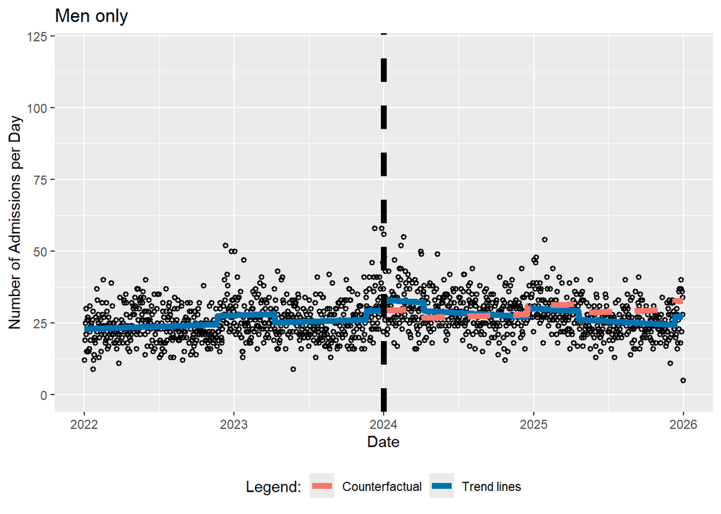

```r
getITSresultsInf(dat0=datsem,outcome="n",ptitle="Men only")
```

```
n ~ Triage_Begin_Day + Level_Change + Slope_Change + influenza
<environment: 0x000002672f14b6d8>
Generalized least squares fit by REML
  Model: form
  Data: dat0
       AIC      BIC    logLik
  9644.489 9681.474 -4815.245

Correlation Structure: AR(1)
 Formula: ~Triage_Begin_Day
 Parameter estimate(s):
      Phi
0.1280139

Coefficients:
                     Value Std.Error  t-value p-value
(Intercept)      24.861788 0.5515659 45.07492   0e+00
Triage_Begin_Day  0.005166 0.0013309  3.88175   1e-04
Level_Change      4.342654 0.7788484  5.57574   0e+00
Slope_Change     -0.013537 0.0019110 -7.08366   0e+00
influenza         2.854636 0.4442439  6.42583   0e+00

 Correlation:
                 (Intr) Tr_B_D Lvl_Ch Slp_Ch
Triage_Begin_Day -0.844
Level_Change      0.355 -0.593
Slope_Change      0.584 -0.721 -0.009
influenza        -0.033 -0.191 -0.042  0.258

Standardized residuals:
        Min          Q1         Med          Q3         Max
-3.31956724 -0.67523459 -0.07500497  0.65882262  5.56639047

Residual standard error: 6.544443
Degrees of freedom: 1461 total; 1456 residual
[1] "Below are the model estimates together with their 95% confidence limits."
                 Point estimates        2.5 %       97.5 %
(Intercept)         24.861788109 23.780738841 25.942837376
Triage_Begin_Day     0.005166154  0.002557672  0.007774637
Level_Change         4.342653903  2.816139047  5.869168759
```

[output cut: 33 more lines]

```
Triage_Begin_Day == 0  0.005166  0.001834  0.008498
Level_Change == 0      4.342654  2.392921  6.292387
Slope_Change == 0     -0.013537 -0.018321 -0.008753
influenza == 0         2.854636  1.742537  3.966736

[1] "Below is the output requested by Alexander Braun"
                   (Intercept)
model_intercept       24.86179
model_pre_slope        0.00517
model_level_change     4.34265
model_slope_change    -0.01354
model_influenza        2.85464
model_AIC           9644.48940
model_BIC           9681.47353
model_n             1461.00000
```

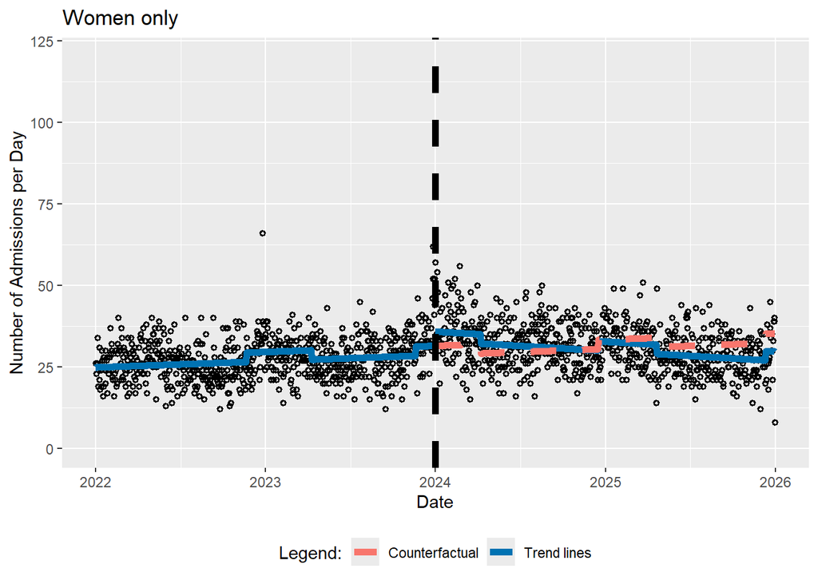

```r
getITSresultsInf(dat0=datsef,outcome="n",ptitle="Women only")
```

```
n ~ Triage_Begin_Day + Level_Change + Slope_Change + influenza
<environment: 0x000002672f0565f0>
Generalized least squares fit by REML
  Model: form
  Data: dat0
       AIC      BIC   logLik
  9103.361 9140.345 -4544.68

Correlation Structure: AR(1)
 Formula: ~Triage_Begin_Day
 Parameter estimate(s):
      Phi
0.3490115

Coefficients:
                     Value Std.Error   t-value p-value
(Intercept)      10.995993 0.6131733 17.932930  0.0000
Triage_Begin_Day  0.003620 0.0014784  2.448513  0.0145
Level_Change      3.635928 0.8638114  4.209169  0.0000
Slope_Change     -0.018959 0.0021245 -8.924178  0.0000
influenza         2.620889 0.4903746  5.344667  0.0000

 Correlation:
                 (Intr) Tr_B_D Lvl_Ch Slp_Ch
Triage_Begin_Day -0.844
Level_Change      0.354 -0.592
Slope_Change      0.584 -0.721 -0.008
influenza        -0.032 -0.190 -0.041  0.255

Standardized residuals:
        Min          Q1         Med          Q3         Max
-2.58310735 -0.66683304 -0.02697302  0.56935990  4.99538837

Residual standard error: 5.757066
Degrees of freedom: 1461 total; 1456 residual
[1] "Below are the model estimates together with their 95% confidence limits."
                 Point estimates         2.5 %       97.5 %
(Intercept)         10.995993362  9.7941958484 12.197790876
Triage_Begin_Day     0.003619773  0.0007222492  0.006517297
Level_Change         3.635928154  1.9428888345  5.328967474
```

[output cut: 33 more lines]

```
Triage_Begin_Day == 0  3.620e-03 -7.962e-05  7.319e-03
Level_Change == 0      3.636e+00  1.474e+00  5.798e+00
Slope_Change == 0     -1.896e-02 -2.428e-02 -1.364e-02
influenza == 0         2.621e+00  1.394e+00  3.848e+00

[1] "Below is the output requested by Alexander Braun"
                   (Intercept)
model_intercept       10.99599
model_pre_slope        0.00362
model_level_change     3.63593
model_slope_change    -0.01896
model_influenza        2.62089
model_AIC           9103.36068
model_BIC           9140.34482
model_n             1461.00000
```

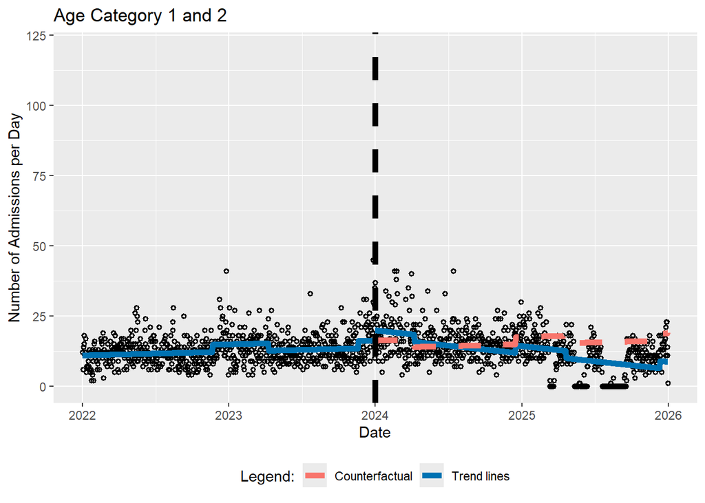

```r
getITSresultsInf(dat0=datag12,outcome="n",ptitle="Age Category 1 and 2")
```

```
n ~ Triage_Begin_Day + Level_Change + Slope_Change + influenza
<environment: 0x000002672f058040>
Generalized least squares fit by REML
  Model: form
  Data: dat0
       AIC     BIC    logLik
  9003.526 9040.51 -4494.763

Correlation Structure: AR(1)
 Formula: ~Triage_Begin_Day
 Parameter estimate(s):
      Phi
0.2883483

Coefficients:
                     Value Std.Error   t-value p-value
(Intercept)      14.227095 0.5421346 26.242739  0.0000
Triage_Begin_Day  0.002984 0.0013075  2.282034  0.0226
Level_Change      1.951099 0.7644601  2.552258  0.0108
Slope_Change     -0.001271 0.0018784 -0.676911  0.4986
influenza         0.904311 0.4347622  2.080012  0.0377

 Correlation:
                 (Intr) Tr_B_D Lvl_Ch Slp_Ch
Triage_Begin_Day -0.844
Level_Change      0.354 -0.593
Slope_Change      0.584 -0.721 -0.008
influenza        -0.032 -0.190 -0.041  0.256

Standardized residuals:
        Min          Q1         Med          Q3         Max
-3.58514333 -0.68718827 -0.07010336  0.57594474  5.69046348

Residual standard error: 5.44291
Degrees of freedom: 1461 total; 1456 residual
[1] "Below are the model estimates together with their 95% confidence limits."
                 Point estimates         2.5 %       97.5 %
(Intercept)         14.227095340 13.1645311460 15.289659534
Triage_Begin_Day     0.002983769  0.0004211082  0.005546431
Level_Change         1.951098953  0.4527847445  3.449413162
```

[output cut: 33 more lines]

```
Triage_Begin_Day == 0  0.0029838 -0.0002871  0.0062546
Level_Change == 0      1.9510990  0.0387133  3.8634846
Slope_Change == 0     -0.0012715 -0.0059704  0.0034274
influenza == 0         0.9043106 -0.1832974  1.9919187

[1] "Below is the output requested by Alexander Braun"
                   (Intercept)
model_intercept       14.22710
model_pre_slope        0.00298
model_level_change     1.95110
model_slope_change    -0.00127
model_influenza        0.90431
model_AIC           9003.52554
model_BIC           9040.50968
model_n             1461.00000
```

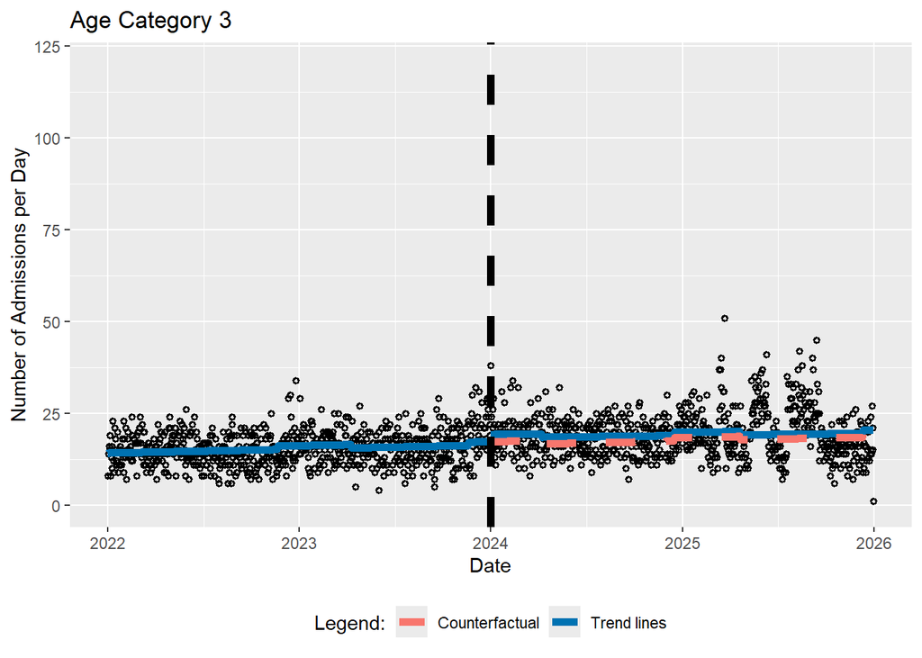

```r
getITSresultsInf(dat0=datag3,outcome="n",ptitle="Age Category 3")
```

```
n ~ Triage_Begin_Day + Level_Change + Slope_Change + influenza
<environment: 0x000002672eb87e78>
Generalized least squares fit by REML
  Model: form
  Data: dat0
      AIC      BIC    logLik
  8242.55 8279.534 -4114.275

Correlation Structure: AR(1)
 Formula: ~Triage_Begin_Day
 Parameter estimate(s):
       Phi
0.03429678

Coefficients:
                     Value Std.Error  t-value p-value
(Intercept)      12.017288 0.3077530 39.04848  0.0000
Triage_Begin_Day  0.000840 0.0007427  1.13103  0.2582
Level_Change      1.141565 0.4347456  2.62582  0.0087
Slope_Change     -0.001458 0.0010663 -1.36747  0.1717
influenza         1.378943 0.2482173  5.55539  0.0000

 Correlation:
                 (Intr) Tr_B_D Lvl_Ch Slp_Ch
Triage_Begin_Day -0.844
Level_Change      0.356 -0.593
Slope_Change      0.584 -0.721 -0.009
influenza        -0.033 -0.191 -0.042  0.259

Standardized residuals:
        Min          Q1         Med          Q3         Max
-2.42461828 -0.67459537 -0.05624045  0.60010279  4.20733371

Residual standard error: 4.011498
Degrees of freedom: 1461 total; 1456 residual
[1] "Below are the model estimates together with their 95% confidence limits."
                 Point estimates         2.5 %       97.5 %
(Intercept)        12.0172883018 11.4141034267 1.262047e+01
Triage_Begin_Day    0.0008400006 -0.0006156346 2.295636e-03
Level_Change        1.1415648007  0.2894791645 1.993650e+00
```

[output cut: 33 more lines]

```
Triage_Begin_Day == 0  0.000840 -0.001020  0.002700
Level_Change == 0      1.141565  0.053057  2.230073
Slope_Change == 0     -0.001458 -0.004128  0.001212
influenza == 0         1.378943  0.757462  2.000425

[1] "Below is the output requested by Alexander Braun"
                   (Intercept)
model_intercept       12.01729
model_pre_slope        0.00084
model_level_change     1.14156
model_slope_change    -0.00146
model_influenza        1.37894
model_AIC           8242.55007
model_BIC           8279.53420
model_n             1461.00000
```

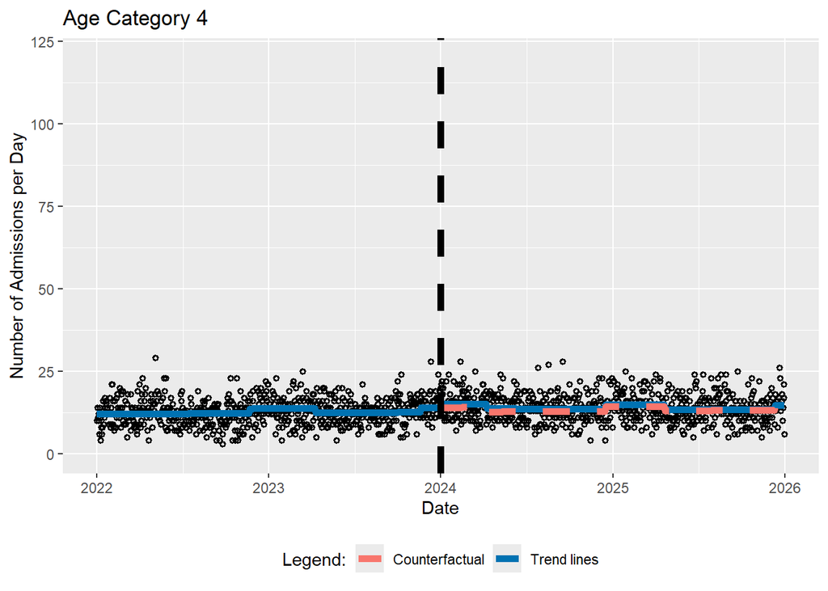

```r
getITSresultsInf(dat0=datag4,outcome="n",ptitle="Age Category 4")
```

```
n ~ Triage_Begin_Day + Level_Change + Slope_Change + influenza
<environment: 0x000002672f4183c8>
Generalized least squares fit by REML
  Model: form
  Data: dat0
       AIC     BIC    logLik
  8174.376 8211.36 -4080.188

Correlation Structure: AR(1)
 Formula: ~Triage_Begin_Day
 Parameter estimate(s):
       Phi
0.05729748

Coefficients:
                     Value Std.Error  t-value p-value
(Intercept)      10.582233 0.3079646 34.36185  0.0000
Triage_Begin_Day  0.002388 0.0007432  3.21281  0.0013
Level_Change      1.338158 0.4350086  3.07616  0.0021
Slope_Change     -0.004744 0.0010670 -4.44620  0.0000
influenza         0.818100 0.2483155  3.29460  0.0010

 Correlation:
                 (Intr) Tr_B_D Lvl_Ch Slp_Ch
Triage_Begin_Day -0.844
Level_Change      0.355 -0.593
Slope_Change      0.584 -0.721 -0.009
influenza        -0.033 -0.191 -0.042  0.258

Standardized residuals:
        Min          Q1         Med          Q3         Max
-2.55372398 -0.71796306 -0.05003809  0.62792232  3.52861221

Residual standard error: 3.923133
Degrees of freedom: 1461 total; 1456 residual
[1] "Below are the model estimates together with their 95% confidence limits."
                 Point estimates        2.5 %       97.5 %
(Intercept)         10.582233360  9.978633899 11.185832820
Triage_Begin_Day     0.002387682  0.000931086  0.003844277
Level_Change         1.338157659  0.485556549  2.190758770
```

[output cut: 33 more lines]

```
Triage_Begin_Day == 0  0.0023877  0.0005283  0.0042470
Level_Change == 0      1.3381577  0.2498009  2.4265145
Slope_Change == 0     -0.0047442 -0.0074138 -0.0020746
influenza == 0         0.8181001  0.1968344  1.4393657

[1] "Below is the output requested by Alexander Braun"
                   (Intercept)
model_intercept       10.58223
model_pre_slope        0.00239
model_level_change     1.33816
model_slope_change    -0.00474
model_influenza        0.81810
model_AIC           8174.37583
model_BIC           8211.35997
model_n             1461.00000
```

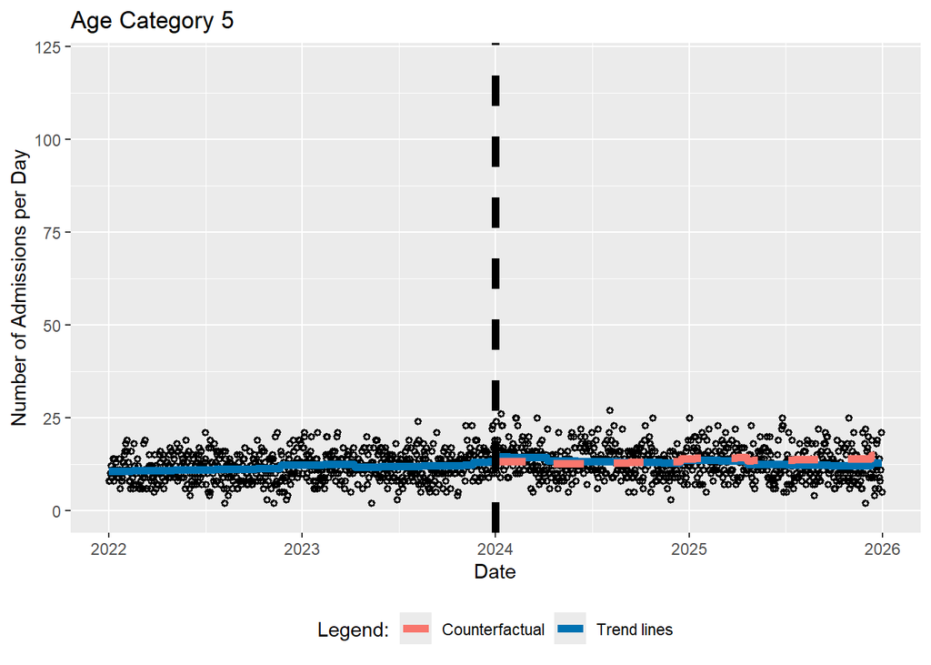

```r
getITSresultsInf(dat0=datag5,outcome="n",ptitle="Age Category 5")
```

```
n ~ Triage_Begin_Day + Level_Change + Slope_Change + influenza
<environment: 0x000002672f2b7190>
Generalized least squares fit by REML
  Model: form
  Data: dat0
       AIC      BIC   logLik
  7129.239 7166.223 -3557.62

Correlation Structure: AR(1)
 Formula: ~Triage_Begin_Day
 Parameter estimate(s):
       Phi
0.09275989

Coefficients:
                     Value  Std.Error   t-value p-value
(Intercept)       5.973988 0.22349811 26.729481  0.0000
Triage_Begin_Day -0.000427 0.00053931 -0.791334  0.4289
Level_Change      1.010878 0.31565052  3.202522  0.0014
Slope_Change     -0.001780 0.00077436 -2.299135  0.0216
influenza         0.405898 0.18011726  2.253522  0.0244

 Correlation:
                 (Intr) Tr_B_D Lvl_Ch Slp_Ch
Triage_Begin_Day -0.844
Level_Change      0.355 -0.593
Slope_Change      0.584 -0.721 -0.009
influenza        -0.033 -0.191 -0.042  0.258

Standardized residuals:
        Min          Q1         Med          Q3         Max
-2.32485654 -0.70084576 -0.06407648  0.65127154  4.65892232

Residual standard error: 2.747769
Degrees of freedom: 1461 total; 1456 residual
[1] "Below are the model estimates together with their 95% confidence limits."
                 Point estimates        2.5 %        97.5 %
(Intercept)         5.9739884983  5.535940253  6.4120367434
Triage_Begin_Day   -0.0004267779 -0.001483816  0.0006302596
Level_Change        1.0108778487  0.392214189  1.6295415088
```

[output cut: 33 more lines]

```
Triage_Begin_Day == 0 -0.0004268 -0.0017752  0.0009217
Level_Change == 0      1.0108778  0.2216532  1.8001025
Slope_Change == 0     -0.0017804 -0.0037165  0.0001558
influenza == 0         0.4058983 -0.0444510  0.8562476

[1] "Below is the output requested by Alexander Braun"
                   (Intercept)
model_intercept        5.97399
model_pre_slope       -0.00043
model_level_change     1.01088
model_slope_change    -0.00178
model_influenza        0.40590
model_AIC           7129.23925
model_BIC           7166.22339
model_n             1461.00000
```

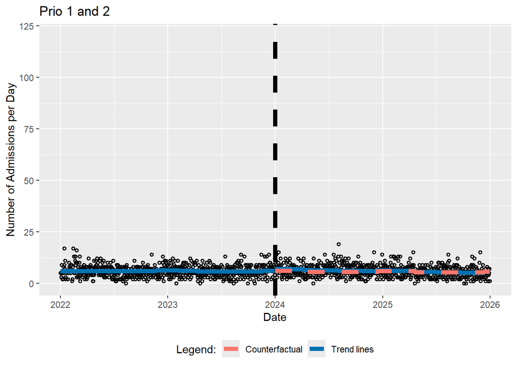

```r
getITSresultsInf(dat0=datpr12,outcome="n",ptitle="Prio 1 and 2")
```

```
n ~ Triage_Begin_Day + Level_Change + Slope_Change + influenza
<environment: 0x000002672f291d98>
Generalized least squares fit by REML
  Model: form
  Data: dat0
       AIC      BIC  logLik
  9276.799 9313.783 -4631.4

Correlation Structure: AR(1)
 Formula: ~Triage_Begin_Day
 Parameter estimate(s):
       Phi
0.05089041

Coefficients:
                     Value Std.Error  t-value p-value
(Intercept)      16.740935 0.4466579 37.48044   0e+00
Triage_Begin_Day  0.007981 0.0010779  7.40441   0e+00
Level_Change      2.396005 0.6309319  3.79756   2e-04
Slope_Change     -0.014166 0.0015476 -9.15386   0e+00
influenza         2.428350 0.3601759  6.74212   0e+00

 Correlation:
                 (Intr) Tr_B_D Lvl_Ch Slp_Ch
Triage_Begin_Day -0.844
Level_Change      0.356 -0.593
Slope_Change      0.584 -0.721 -0.009
influenza        -0.033 -0.191 -0.042  0.258

Standardized residuals:
        Min          Q1         Med          Q3         Max
-3.08177979 -0.67349996 -0.06219026  0.61097619  4.88355214

Residual standard error: 5.726472
Degrees of freedom: 1461 total; 1456 residual
[1] "Below are the model estimates together with their 95% confidence limits."
                 Point estimates        2.5 %      97.5 %
(Intercept)         16.740935374 15.865501895 17.61636885
Triage_Begin_Day     0.007981035  0.005868437  0.01009363
Level_Change         2.396004702  1.159400827  3.63260858
```

[output cut: 33 more lines]

```
Triage_Begin_Day == 0  0.007981  0.005280  0.010682
Level_Change == 0      2.396005  0.814818  3.977191
Slope_Change == 0     -0.014166 -0.018044 -0.010288
influenza == 0         2.428350  1.525708  3.330991

[1] "Below is the output requested by Alexander Braun"
                   (Intercept)
model_intercept       16.74094
model_pre_slope        0.00798
model_level_change     2.39600
model_slope_change    -0.01417
model_influenza        2.42835
model_AIC           9276.79923
model_BIC           9313.78337
model_n             1461.00000
```

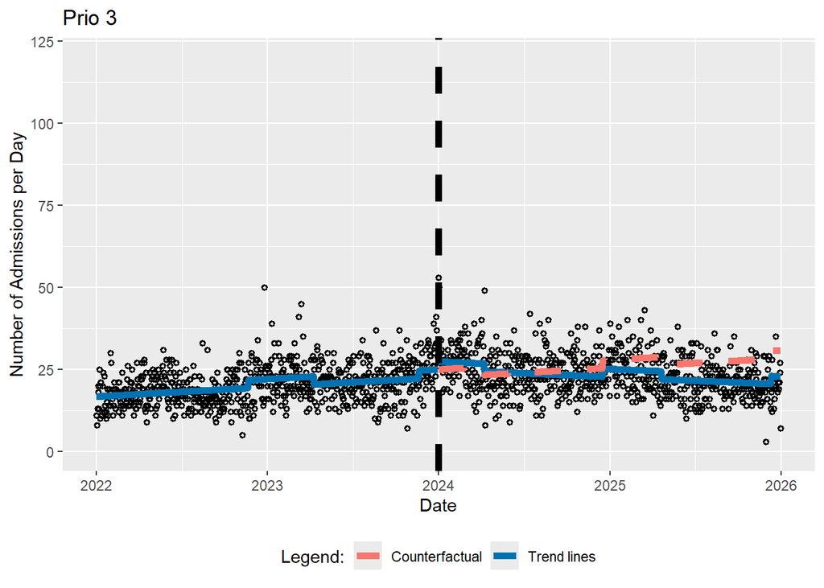

```r
getITSresultsInf(dat0=datpr3,outcome="n",ptitle="Prio 3")
```

```
n ~ Triage_Begin_Day + Level_Change + Slope_Change + influenza
<environment: 0x000002672d76f458>
Generalized least squares fit by REML
  Model: form
  Data: dat0
       AIC      BIC    logLik
  9911.556 9948.541 -4948.778

Correlation Structure: AR(1)
 Formula: ~Triage_Begin_Day
 Parameter estimate(s):
      Phi
0.1372317

Coefficients:
                     Value Std.Error  t-value p-value
(Intercept)      25.090692 0.6109968 41.06518  0.0000
Triage_Begin_Day  0.002259 0.0014743  1.53210  0.1257
Level_Change      4.557025 0.8627239  5.28214  0.0000
Slope_Change     -0.010228 0.0021170 -4.83154  0.0000
influenza         3.027693 0.4920268  6.15351  0.0000

 Correlation:
                 (Intr) Tr_B_D Lvl_Ch Slp_Ch
Triage_Begin_Day -0.844
Level_Change      0.355 -0.593
Slope_Change      0.584 -0.721 -0.009
influenza        -0.033 -0.191 -0.042  0.258

Standardized residuals:
        Min          Q1         Med          Q3         Max
-3.27319930 -0.66000725 -0.07843921  0.58310574  6.02098622

Residual standard error: 7.182221
Degrees of freedom: 1461 total; 1456 residual
[1] "Below are the model estimates together with their 95% confidence limits."
                 Point estimates         2.5 %       97.5 %
(Intercept)         25.090692118 23.8931604155 26.288223821
Triage_Begin_Day     0.002258705 -0.0006307893  0.005148199
Level_Change         4.557025327  2.8661175122  6.247933142
```

[output cut: 33 more lines]

```
Triage_Begin_Day == 0  0.002259 -0.001432  0.005949
Level_Change == 0      4.557025  2.397322  6.716729
Slope_Change == 0     -0.010228 -0.015528 -0.004929
influenza == 0         3.027693  1.795975  4.259410

[1] "Below is the output requested by Alexander Braun"
                   (Intercept)
model_intercept       25.09069
model_pre_slope        0.00226
model_level_change     4.55703
model_slope_change    -0.01023
model_influenza        3.02769
model_AIC           9911.55638
model_BIC           9948.54052
model_n             1461.00000
```

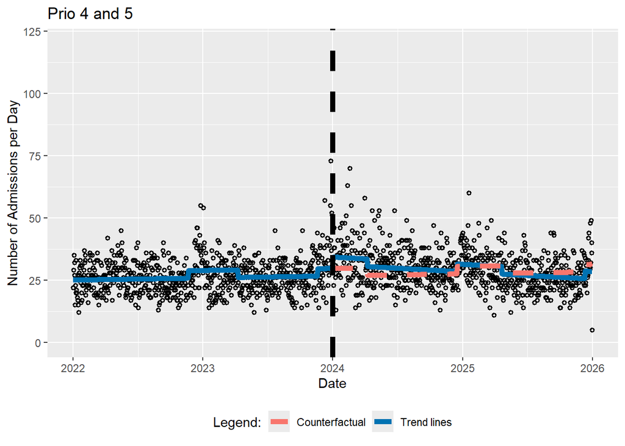

```r
getITSresultsInf(dat0=datpr45,outcome="n",ptitle="Prio 4 and 5")
```

```
n ~ Triage_Begin_Day + Level_Change + Slope_Change + influenza
<environment: 0x000002672e149500>
Generalized least squares fit by REML
  Model: form
  Data: dat0
       AIC      BIC    logLik
  7720.332 7754.947 -3853.166

Correlation Structure: ARMA(1,0)
 Formula: ~Triage_Begin_Day
 Parameter estimate(s):
     Phi1
0.1880405

Coefficients:
                    Value Std.Error  t-value p-value
(Intercept)      49.78810 1.0010615 49.73531  0.0000
Triage_Begin_Day  0.00656 0.0024169  2.71535  0.0067
Level_Change      7.11975 1.4096253  5.05081  0.0000
Slope_Change     -0.01995 0.0034576 -5.76944  0.0000
influenza         5.09789 0.8039358  6.34116  0.0000

 Correlation:
                 (Intr) Tr_B_D Lvl_Ch Slp_Ch
Triage_Begin_Day -0.844
Level_Change      0.358 -0.596
Slope_Change      0.586 -0.723 -0.002
influenza        -0.033 -0.190 -0.042  0.258

Standardized residuals:
        Min          Q1         Med          Q3         Max
-4.48830225 -0.70512083 -0.05332372  0.57280632  6.15234772

Residual standard error: 9.81025
Degrees of freedom: 1043 total; 1038 residual
[1] "Below are the model estimates together with their 95% confidence limits."
                 Point estimates        2.5 %      97.5 %
(Intercept)         49.788099516 47.826055099 51.75014393
Triage_Begin_Day     0.006562674  0.001825682  0.01129967
Level_Change         7.119754542  4.356939652  9.88256943
```

[output cut: 33 more lines]

```
Triage_Begin_Day == 0  0.0065627  0.0005159  0.0126094
Level_Change == 0      7.1197545  3.5930250 10.6464841
Slope_Change == 0     -0.0199485 -0.0285991 -0.0112980
influenza == 0         5.0978895  3.0865294  7.1092497

[1] "Below is the output requested by Alexander Braun"
                   (Intercept)
model_intercept       49.78810
model_pre_slope        0.00656
model_level_change     7.11975
model_slope_change    -0.01995
model_influenza        5.09789
model_AIC           7720.33201
model_BIC           7754.94737
model_n             1043.00000
```

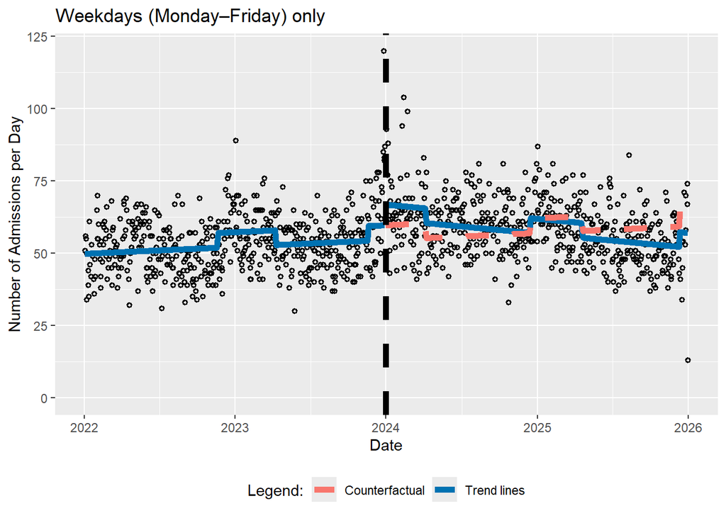

```r
getITSresultsInf(dat0=datwk,outcome="n",ptitle="Weekdays (Monday–Friday) only")
```

```
n ~ Triage_Begin_Day + Level_Change + Slope_Change + influenza
<environment: 0x000002672cd60040>
Generalized least squares fit by REML
  Model: form
  Data: dat0
       AIC      BIC    logLik
  3200.457 3228.622 -1593.229

Correlation Structure: ARMA(1,0)
 Formula: ~Triage_Begin_Day
 Parameter estimate(s):
      Phi1
0.08967834

Coefficients:
                    Value Std.Error   t-value p-value
(Intercept)      43.10923 1.5576664 27.675518       0
Triage_Begin_Day  0.01832 0.0037550  4.878708       0
Level_Change     10.15772 2.2183475  4.578957       0
Slope_Change     -0.04211 0.0054333 -7.749587       0
influenza         7.88377 1.2678822  6.218064       0

 Correlation:
                 (Intr) Tr_B_D Lvl_Ch Slp_Ch
Triage_Begin_Day -0.842
Level_Change      0.349 -0.587
Slope_Change      0.578 -0.715 -0.024
influenza        -0.031 -0.194 -0.043  0.259

Standardized residuals:
        Min          Q1         Med          Q3         Max
-2.65036143 -0.66473962 -0.08225554  0.63567037  5.38494756

Residual standard error: 10.85068
Degrees of freedom: 418 total; 413 residual
[1] "Below are the model estimates together with their 95% confidence limits."
                 Point estimates      2.5 %      97.5 %
(Intercept)          43.10922516 40.0562551 46.16219520
Triage_Begin_Day      0.01831941  0.0109598  0.02567902
Level_Change         10.15771760  5.8098363 14.50559888
```

[output cut: 33 more lines]

```
Triage_Begin_Day == 0  0.018319  0.008906  0.027733
Level_Change == 0     10.157718  4.596250 15.719185
Slope_Change == 0     -0.042106 -0.055727 -0.028484
influenza == 0         7.883772  4.705152 11.062393

[1] "Below is the output requested by Alexander Braun"
                   (Intercept)
model_intercept       43.10923
model_pre_slope        0.01832
model_level_change    10.15772
model_slope_change    -0.04211
model_influenza        7.88377
model_AIC           3200.45748
model_BIC           3228.62161
model_n              418.00000
```

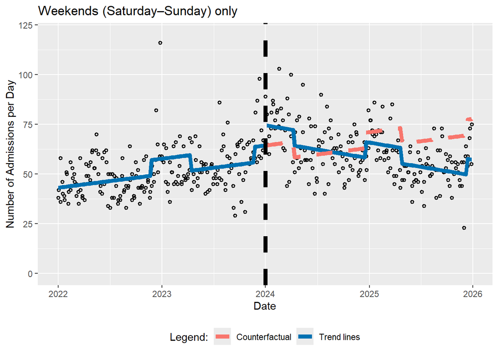

```r
getITSresultsInf(dat0=datss,outcome="n",ptitle="Weekends (Saturday–Sunday) only")
```

# How do I perform the ITSA accounting for influenza, holidays, and day of the week?

```
n ~ Triage_Begin_Day + Level_Change + Slope_Change + influenza +
    Holiday + WD2 + WD3 + WD4 + WD5 + WD6 + WD7
<environment: 0x0000026735b7f438>
Generalized least squares fit by REML
  Model: form
  Data: dat0
       AIC      BIC    logLik
  10823.22 10897.12 -5397.612

Correlation Structure: AR(1)
 Formula: ~Triage_Begin_Day
 Parameter estimate(s):
      Phi
0.1612854

Coefficients:
                    Value Std.Error  t-value p-value
(Intercept)      52.98309 1.0589001 50.03597  0.0000
Triage_Begin_Day  0.00981 0.0020763  4.72535  0.0000
Level_Change      8.01474 1.2149625  6.59670  0.0000
Slope_Change     -0.02629 0.0029816 -8.81861  0.0000
influenza         5.82106 0.6926832  8.40364  0.0000
Holiday           4.32481 1.3802088  3.13344  0.0018
WD2              -7.03539 0.8878655 -7.92393  0.0000
WD3              -7.46115 0.9552155 -7.81096  0.0000
WD4              -7.12872 0.9644035 -7.39185  0.0000
WD5              -5.71628 0.9665843 -5.91390  0.0000
WD6              -6.25334 0.9556991 -6.54321  0.0000
WD7              -3.69112 0.8867968 -4.16230  0.0000

 Correlation:
                 (Intr) Tr_B_D Lvl_Ch Slp_Ch inflnz Holidy WD2    WD3    WD4
Triage_Begin_Day -0.684
Level_Change      0.286 -0.593
Slope_Change      0.474 -0.721 -0.009
influenza        -0.025 -0.191 -0.042  0.258
Holiday          -0.089 -0.004  0.008 -0.003 -0.009
WD2              -0.423 -0.001  0.002  0.000 -0.001  0.089
WD3              -0.454 -0.002  0.003  0.000 -0.001  0.069  0.542
WD4              -0.452 -0.003  0.003  0.002 -0.001 -0.001  0.468  0.572
```

[output cut: 88 more lines]

```
model_intercept       52.98309
model_pre_slope        0.00981
model_level_change     8.01474
model_slope_change    -0.02629
model_influenza        5.82106
model_holiday          4.32481
model_WD2             -7.03539
model_WD3             -7.46115
model_WD4             -7.12872
model_WD5             -5.71628
model_WD6             -6.25334
model_WD7             -3.69112
model_AIC          10823.22376
model_BIC          10897.12457
model_n             1461.00000
```

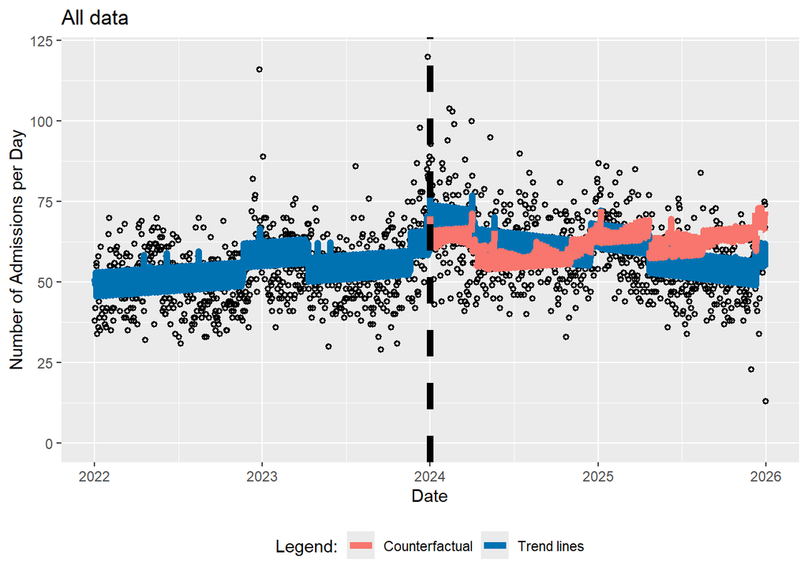

```r
getITSresultsNew(dat0=datnew,outcome="n",ptitle="All data")
```

# How do I perform the ITSA accounting for influenze with different interruption dates?

```
n ~ Triage_Begin_Day + Level_Change + Slope_Change + influenza
<environment: 0x000002673a86a7d0>
Generalized least squares fit by REML
  Model: form
  Data: dat0
       AIC      BIC    logLik
  10899.93 10936.92 -5442.967

Correlation Structure: AR(1)
 Formula: ~Triage_Begin_Day
 Parameter estimate(s):
      Phi
0.1533249

Coefficients:
                    Value Std.Error  t-value p-value
(Intercept)      48.77453 0.8953534 54.47518   0.000
Triage_Begin_Day  0.00626 0.0022240  2.81403   0.005
Level_Change     10.85102 1.2504949  8.67738   0.000
Slope_Change     -0.02336 0.0030329 -7.70052   0.000
influenza         5.20095 0.7109355  7.31564   0.000

 Correlation:
                 (Intr) Tr_B_D Lvl_Ch Slp_Ch
Triage_Begin_Day -0.850
Level_Change      0.368 -0.596
Slope_Change      0.612 -0.752  0.034
influenza        -0.074 -0.113 -0.160  0.242

Standardized residuals:
        Min          Q1         Med          Q3         Max
-4.27285448 -0.70015889 -0.04035678  0.63273820  5.91297248

Residual standard error: 10.10959
Degrees of freedom: 1461 total; 1456 residual
[1] "Below are the model estimates together with their 95% confidence limits."
                 Point estimates        2.5 %      97.5 %
(Intercept)         48.774534913 47.019674571 50.52939525
Triage_Begin_Day     0.006258451  0.001899456  0.01061745
Level_Change        10.851022296  8.400097327 13.30194727
```

[output cut: 33 more lines]

```
Triage_Begin_Day == 0  0.0062585  0.0007011  0.0118158
Level_Change == 0     10.8510223  7.7262943 13.9757502
Slope_Change == 0     -0.0233552 -0.0309338 -0.0157765
influenza == 0         5.2009458  3.4244651  6.9774266

[1] "Below is the output requested by Alexander Braun"
                   (Intercept)
model_intercept       48.77453
model_pre_slope        0.00626
model_level_change    10.85102
model_slope_change    -0.02336
model_influenza        5.20095
model_AIC          10899.93376
model_BIC          10936.91790
model_n             1461.00000
```

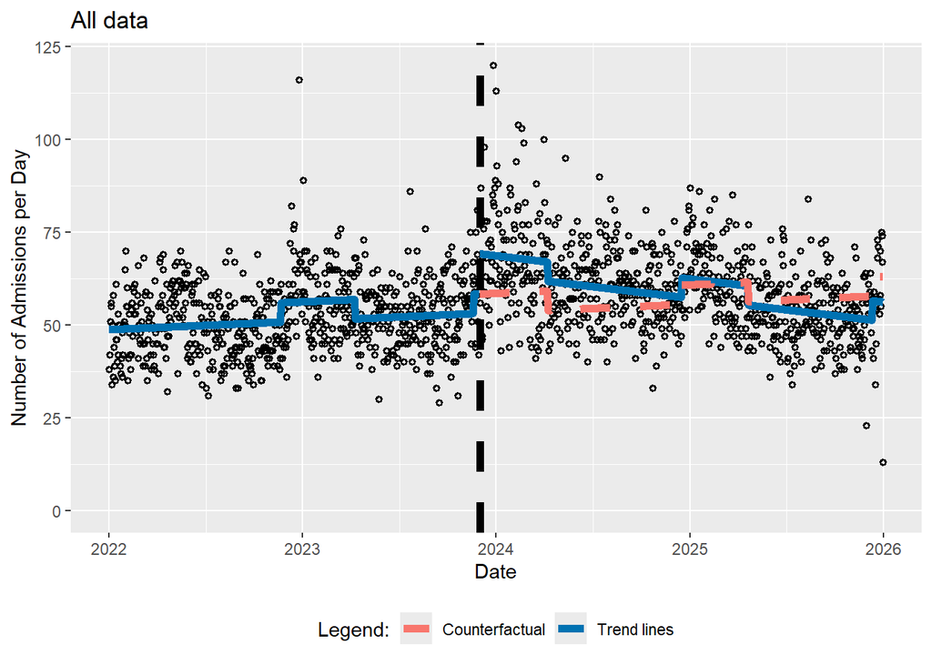

```r
getITSresultsInf(dat0=datalld,outcome="n",ptitle="All data",intday="01Dec2023")
```

```
n ~ Triage_Begin_Day + Level_Change + Slope_Change + influenza
<environment: 0x000002672f4539b0>
Generalized least squares fit by REML
  Model: form
  Data: dat0
       AIC      BIC    logLik
  10932.96 10969.95 -5459.481

Correlation Structure: AR(1)
 Formula: ~Triage_Begin_Day
 Parameter estimate(s):
      Phi
0.1799252

Coefficients:
                    Value Std.Error  t-value p-value
(Intercept)      47.23603 0.8935582 52.86285       0
Triage_Begin_Day  0.01185 0.0021020  5.63681       0
Level_Change      6.02360 1.2920592  4.66202       0
Slope_Change     -0.02811 0.0031739 -8.85768       0
influenza         6.21688 0.7355956  8.45149       0

 Correlation:
                 (Intr) Tr_B_D Lvl_Ch Slp_Ch
Triage_Begin_Day -0.837
Level_Change      0.346 -0.597
Slope_Change      0.555 -0.684 -0.050
influenza         0.000 -0.257  0.075  0.251

Standardized residuals:
       Min         Q1        Med         Q3        Max
-4.2964532 -0.6863088 -0.0462820  0.6160953  5.6746134

Residual standard error: 10.27266
Degrees of freedom: 1461 total; 1456 residual
[1] "Below are the model estimates together with their 95% confidence limits."
                 Point estimates        2.5 %      97.5 %
(Intercept)          47.23602761 45.484685766 48.98736946
Triage_Begin_Day      0.01184874  0.007728834  0.01596864
Level_Change          6.02360172  3.491212237  8.55599119
```

[output cut: 33 more lines]

```
Triage_Begin_Day == 0  0.011849  0.006575  0.017123
Level_Change == 0      6.023602  2.781841  9.265363
Slope_Change == 0     -0.028114 -0.036077 -0.020150
influenza == 0         6.216881  4.371281  8.062481

[1] "Below is the output requested by Alexander Braun"
                   (Intercept)
model_intercept       47.23603
model_pre_slope        0.01185
model_level_change     6.02360
model_slope_change    -0.02811
model_influenza        6.21688
model_AIC          10932.96281
model_BIC          10969.94695
model_n             1461.00000
```

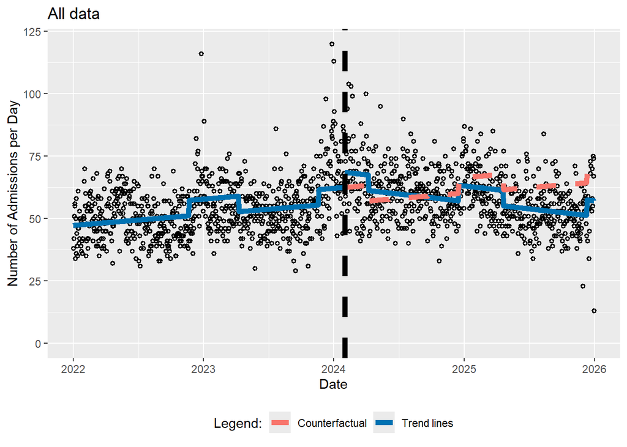

```r
getITSresultsInf(dat0=datallf,outcome="n",ptitle="All data",intday="01Feb2024")
```

```
n ~ Triage_Begin_Day + Level_Change + Slope_Change + influenza
<environment: 0x000002672f256ba0>
Generalized least squares fit by REML
  Model: form
  Data: dat0
       AIC      BIC    logLik
  10941.16 10978.14 -5463.579

Correlation Structure: AR(1)
 Formula: ~Triage_Begin_Day
 Parameter estimate(s):
     Phi
0.186204

Coefficients:
                    Value Std.Error  t-value p-value
(Intercept)      47.01586 0.7658113 61.39353   0.000
Triage_Begin_Day  0.01282 0.0011940 10.73478   0.000
Level_Change     -4.02960 1.5415505 -2.61399   0.009
Slope_Change     -0.03145 0.0066122 -4.75692   0.000
influenza         6.65284 0.7537827  8.82594   0.000

 Correlation:
                 (Intr) Tr_B_D Lvl_Ch Slp_Ch
Triage_Begin_Day -0.830
Level_Change      0.282 -0.398
Slope_Change      0.097 -0.210 -0.675
influenza        -0.184 -0.095 -0.230  0.308

Standardized residuals:
       Min         Q1        Med         Q3        Max
-4.2560602 -0.6882021 -0.0608242  0.6138008  5.5949287

Residual standard error: 10.31828
Degrees of freedom: 1461 total; 1456 residual
[1] "Below are the model estimates together with their 95% confidence limits."
                 Point estimates       2.5 %      97.5 %
(Intercept)          47.01586037 45.51489772 48.51682303
Triage_Begin_Day      0.01281681  0.01047671  0.01515691
Level_Change         -4.02959905 -7.05098254 -1.00821555
```

[output cut: 33 more lines]

```
Triage_Begin_Day == 0  0.01282  0.00982  0.01581
Level_Change == 0     -4.02960 -7.89906 -0.16014
Slope_Change == 0     -0.03145 -0.04805 -0.01486
influenza == 0         6.65284  4.76076  8.54492

[1] "Below is the output requested by Alexander Braun"
                   (Intercept)
model_intercept       47.01586
model_pre_slope        0.01282
model_level_change    -4.02960
model_slope_change    -0.03145
model_influenza        6.65284
model_AIC          10941.15804
model_BIC          10978.14218
model_n             1461.00000
```

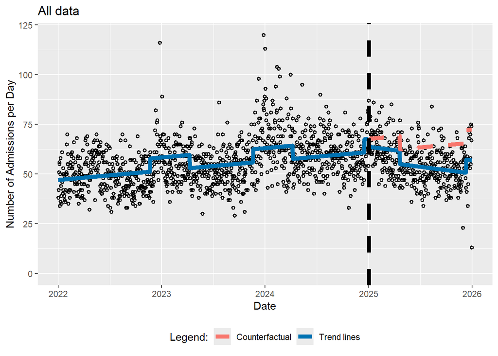

```r
getITSresultsInf(dat0=datall5,outcome="n",ptitle="All data",intday="01Jan2025")
```

# How do I perform the ITSA accounting for influenza using ARMA(1,1) and AR(2) errors?

```
n ~ Triage_Begin_Day + Level_Change + Slope_Change + influenza
<environment: 0x0000026738a9dd60>
Generalized least squares fit by REML
  Model: form
  Data: dat0
      AIC      BIC    logLik
  10907.1 10949.37 -5445.551

Correlation Structure: ARMA(1,1)
 Formula: ~Triage_Begin_Day
 Parameter estimate(s):
      Phi1     Theta1
 0.9140928 -0.8247787

Coefficients:
                    Value Std.Error  t-value p-value
(Intercept)      47.57538 1.4829411 32.08177  0.0000
Triage_Begin_Day  0.01115 0.0035436  3.14540  0.0017
Level_Change      7.25721 2.0327438  3.57015  0.0004
Slope_Change     -0.02719 0.0051426 -5.28739  0.0000
influenza         5.13714 1.0949952  4.69148  0.0000

 Correlation:
                 (Intr) Tr_B_D Lvl_Ch Slp_Ch
Triage_Begin_Day -0.844
Level_Change      0.337 -0.580
Slope_Change      0.592 -0.730 -0.004
influenza        -0.028 -0.180 -0.029  0.226

Standardized residuals:
       Min         Q1        Med         Q3        Max
-4.2283823 -0.6934942 -0.0554386  0.6210806  5.7754987

Residual standard error: 10.26509
Degrees of freedom: 1461 total; 1456 residual
[1] "Below are the model estimates together with their 95% confidence limits."
                 Point estimates       2.5 %      97.5 %
(Intercept)          47.57538065 44.66886951 50.48189179
Triage_Begin_Day      0.01114612  0.00420074  0.01809150
Level_Change          7.25720730  3.27310263 11.24131197
```

[output cut: 33 more lines]

```
Triage_Begin_Day == 0  0.011146  0.002274  0.020019
Level_Change == 0      7.257207  2.167675 12.346739
Slope_Change == 0     -0.027191 -0.040067 -0.014315
influenza == 0         5.137144  2.395523  7.878765

[1] "Below is the output requested by Alexander Braun"
                   (Intercept)
model_intercept       47.57538
model_pre_slope        0.01115
model_level_change     7.25721
model_slope_change    -0.02719
model_influenza        5.13714
model_AIC          10907.10117
model_BIC          10949.36876
model_n             1461.00000
```

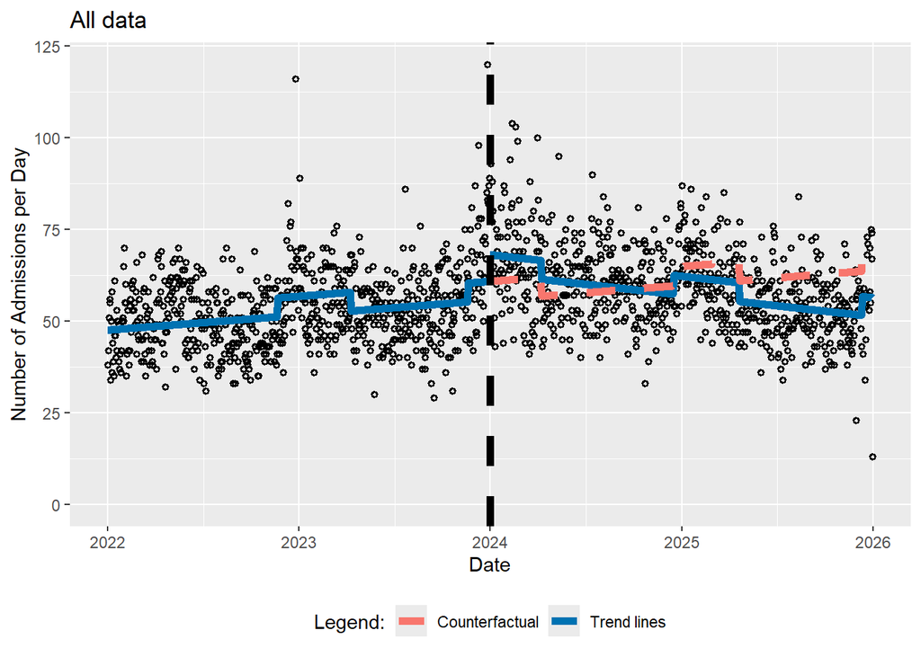

```r
getITSresultsInfARMA11(dat0=datall,outcome="n",ptitle="All data") # ARMA(1,1) - process
```

```
n ~ Triage_Begin_Day + Level_Change + Slope_Change + influenza
<environment: 0x0000026732621370>
Generalized least squares fit by REML
  Model: form
  Data: dat0
       AIC      BIC    logLik
  10922.89 10965.15 -5453.443

Correlation Structure: ARMA(2,0)
 Formula: ~Triage_Begin_Day
 Parameter estimate(s):
      Phi1       Phi2
0.16738381 0.03131965

Coefficients:
                    Value Std.Error  t-value p-value
(Intercept)      47.81368 0.9301976 51.40164       0
Triage_Begin_Day  0.00979 0.0022440  4.36401       0
Level_Change      8.04053 1.3127294  6.12504       0
Slope_Change     -0.02630 0.0032229 -8.16120       0
influenza         5.81696 0.7477546  7.77924       0

 Correlation:
                 (Intr) Tr_B_D Lvl_Ch Slp_Ch
Triage_Begin_Day -0.844
Level_Change      0.355 -0.593
Slope_Change      0.584 -0.721 -0.008
influenza        -0.033 -0.190 -0.042  0.257

Standardized residuals:
        Min          Q1         Med          Q3         Max
-4.28242134 -0.70197210 -0.05916388  0.63034730  5.79784314

Residual standard error: 10.22266
Degrees of freedom: 1461 total; 1456 residual
[1] "Below are the model estimates together with their 95% confidence limits."
                 Point estimates        2.5 %      97.5 %
(Intercept)         47.813682027 45.990528193 49.63683586
Triage_Begin_Day     0.009793042  0.005394796  0.01419129
Level_Change         8.040525380  5.467622979 10.61342778
```

[output cut: 33 more lines]

```
Triage_Begin_Day == 0  0.009793  0.004169  0.015417
Level_Change == 0      8.040525  4.750656 11.330395
Slope_Change == 0     -0.026303 -0.034380 -0.018226
influenza == 0         5.816963  3.942994  7.690933

[1] "Below is the output requested by Alexander Braun"
                   (Intercept)
model_intercept       47.81368
model_pre_slope        0.00979
model_level_change     8.04053
model_slope_change    -0.02630
model_influenza        5.81696
model_AIC          10922.88649
model_BIC          10965.15408
model_n             1461.00000
```

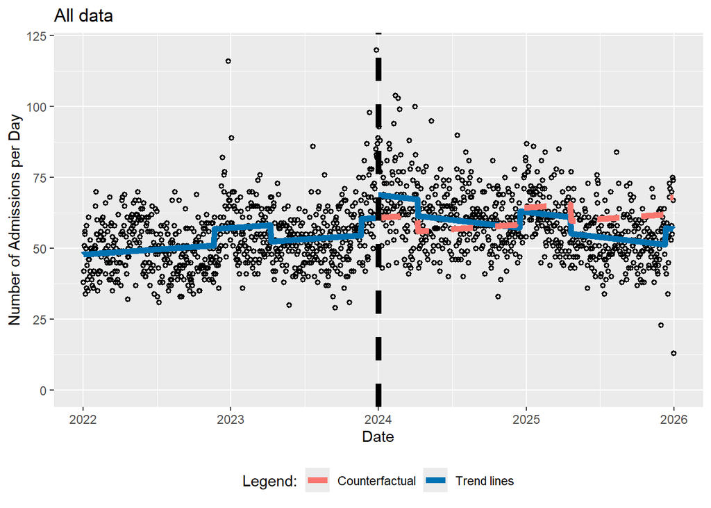

```r
getITSresultsInfAR2(dat0=datall,outcome="n",ptitle="All data") # ARMA(2,0) - process
```

# How do I perform the ITSA with Months?

```
n ~ Triage_Begin_Month + Level_Change + Slope_Change
<environment: 0x000002672f03bd28>
Generalized least squares fit by REML
  Model: form
  Data: dat0
       AIC      BIC    logLik
  583.2494 593.9545 -285.6247

Correlation Structure: AR(1)
 Formula: ~Triage_Begin_Month
 Parameter estimate(s):
      Phi
0.3817266

Coefficients:
                       Value Std.Error   t-value p-value
(Intercept)        1422.3023  83.64773 17.003478  0.0000
Triage_Begin_Month   15.5313   5.73413  2.708562  0.0096
Level_Change        148.7655 105.62948  1.408371  0.1660
Slope_Change        -30.2976   8.47780 -3.573754  0.0009

 Correlation:
                   (Intr) Tr_B_M Lvl_Ch
Triage_Begin_Month -0.865
Level_Change        0.338 -0.591
Slope_Change        0.619 -0.739  0.040

Standardized residuals:
       Min         Q1        Med         Q3        Max
-1.5014169 -0.5776937 -0.2152613  0.5403930  2.6630722

Residual standard error: 141.9217
Degrees of freedom: 48 total; 44 residual
[1] "Below are the model estimates together with their 95% confidence limits."
                   Point estimates      2.5 %     97.5 %
(Intercept)             1422.30228 1258.35575 1586.24882
Triage_Begin_Month        15.53125    4.29256   26.76995
Level_Change             148.76551  -58.26447  355.79550
Slope_Change             -30.29756  -46.91374  -13.68138
[1] "Below are the model estimates together with multiplicity adjusted p-values and confidence limits"
```

[output cut: 27 more lines]

```
                        Estimate  lwr       upr
(Intercept) == 0        1422.3023 1221.8577 1622.7469
Triage_Begin_Month == 0   15.5313    1.7906   29.2719
Level_Change == 0        148.7655 -104.3538  401.8849
Slope_Change == 0        -30.2976  -50.6129   -9.9823

[1] "Below is the output requested by Alexander Braun"
                   (Intercept)
model_intercept     1422.30228
model_pre_slope       15.53125
model_level_change   148.76551
model_slope_change   -30.29756
model_AIC            583.24937
model_BIC            593.95451
model_n               48.00000
```

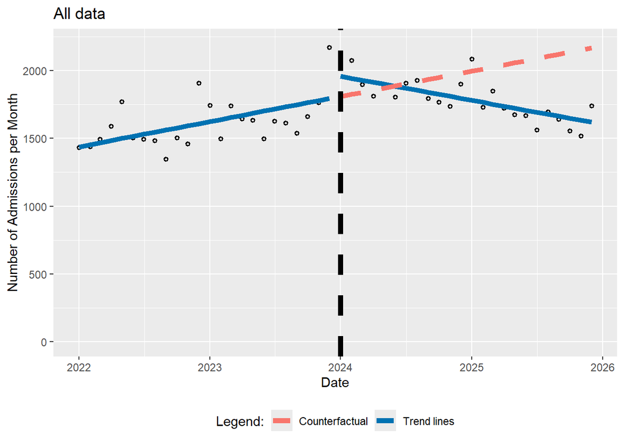

```r
getITSresultsMonth(dat0=datallm,outcome="n",ptitle="All data")
```

# How do I estimate the time series trend using the semiparametric model suggested by Feng et al.?

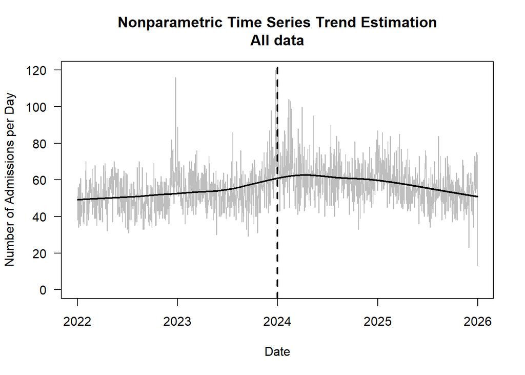

```r
getnts(dat0=datall,ptitle="All data")
```

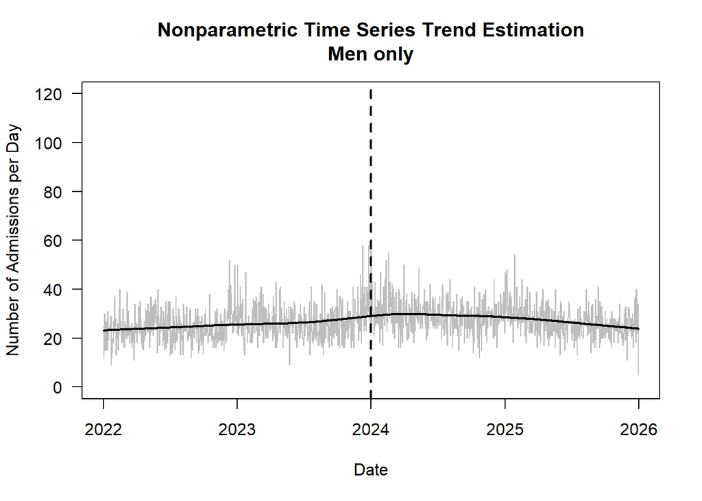

```r
getnts(dat0=datsem,ptitle="Men only")
```

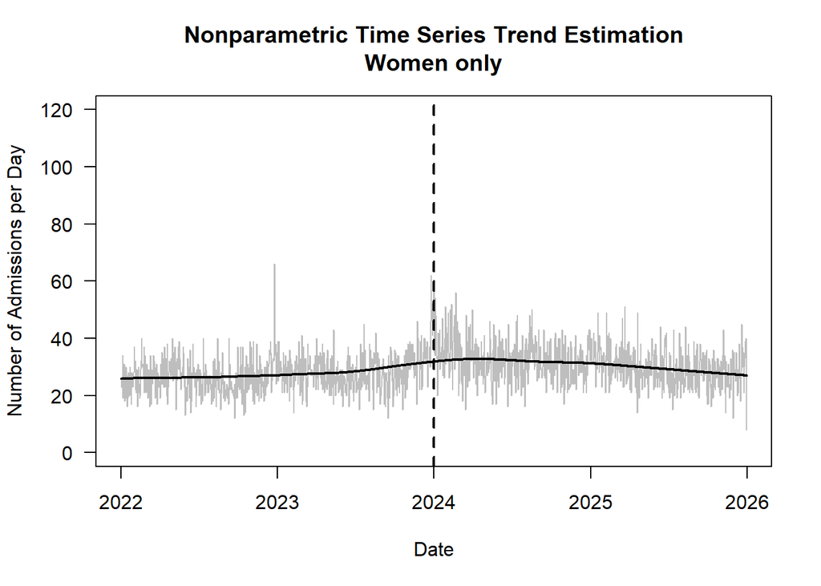

```r
getnts(dat0=datsef,ptitle="Women only")
```

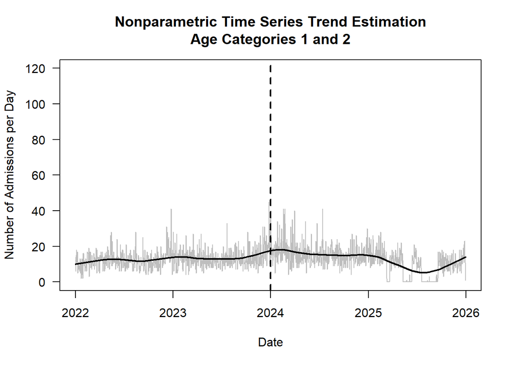

```r
getnts(dat0=datag12,ptitle="Age Categories 1 and 2")
```

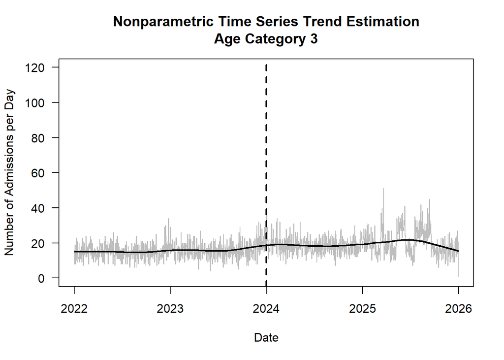

```r
getnts(dat0=datag3,ptitle="Age Category 3")
```

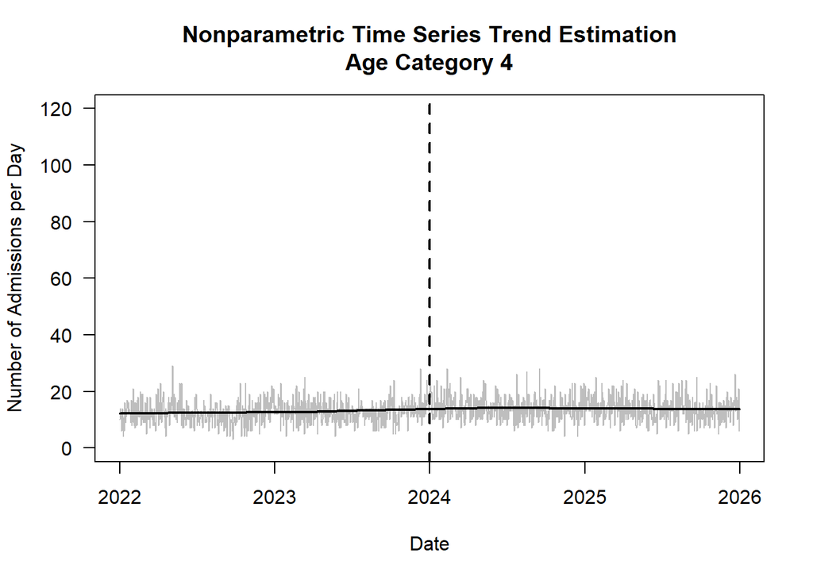

```r
getnts(dat0=datag4,ptitle="Age Category 4")
```

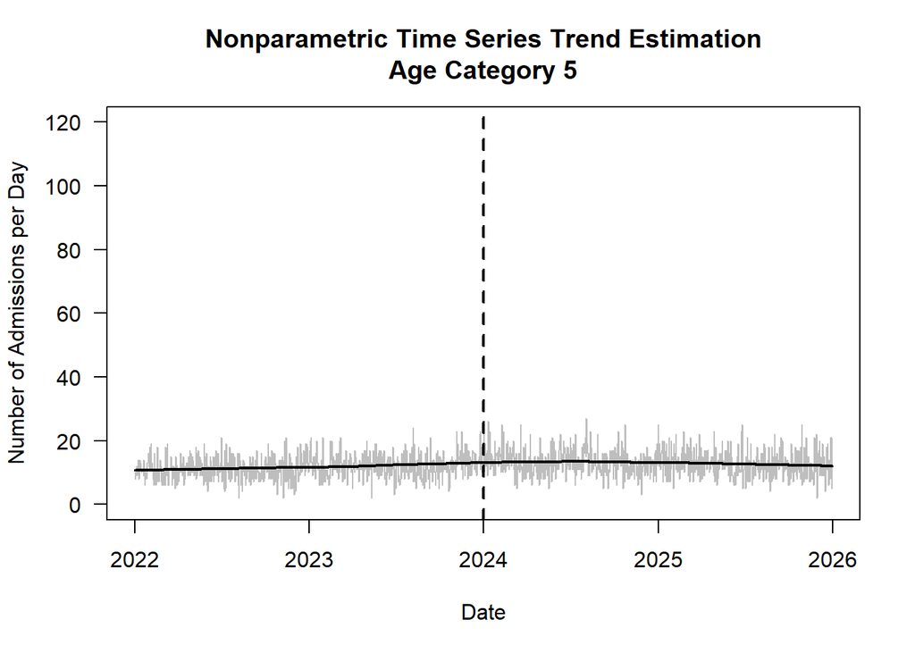

```r
getnts(dat0=datag5,ptitle="Age Category 5")
```